# SPINE_analysis

Rachael Burke

2020/10/07

RMD document for analysis for spine paper

## 0. Setup

Load the required libraries and data

```r
## NB. one of these has "MASS" as a dependency, MASS also has 'select' as a function, so when you want normal 'select', need to specify dplyr::select
library(tidyverse)
library(lubridate)
library(knitr)
library(here)
library(janitor)
library(gt)
library(markdown)
library(ggtext)
library(naniar)
library(arsenal)
library(wesanderson)

library(rcompanion)
library(modelr)
library(vcd)
library(emmeans)
library(fitdistrplus)
library(splines)
library(rms)
library(stats)
library(Amelia)
library(mice)
library(boot)
library(broom)

load(here("data-raw", "spine.rda"))
spine <- spine
spine <- spine %>%
  dplyr::select(outcome,sex,quarter,ageg10,hiv,art) %>%  # this reduces dates to "quarter", may be better with dates as continuous?
  mutate(hiv=as.factor(hiv)) %>%
    mutate(hiv=fct_recode(hiv, "Negative" = "NON-REACTIVE",
                           "Positive" = "REACTIVE")) %>%
    mutate(art2 = case_when(art=="CONFIRMED DEFAULTER" ~ "no_art",
         art=="NO" ~ "no_art",
         art=="YES" ~ "yes_art")) %>%
  mutate(art2=if_else(is.na(hiv),"999",art2)) %>%
  mutate(art2=na_if(art2,"999")) %>% #need to revert to NA - I can't work out how to do this in one go!
  mutate(art=art2) %>%
  mutate(art=as.factor(art)) %>%
  dplyr::select(-art2)
# spine <- spine_summary %>%  # make summary data into tidy data
#   as_tibble() %>%
#   mutate(obs = map(n, ~rep_len(1, .x))) %>%
#   unnest(cols=c(obs)) %>%
#   dplyr::select(-n, -obs)

load(here("data", "cens_edit.rda"))
cens_edit <- cens_edit

# from https://gist.github.com/andrewheiss/a3134085e92c6607db39c5b14e1b879e (with some tweaks made)
 meld_predictions <- function(x) {
  x_melded <- mi.meld(matrix(x$.fitted), matrix(x$.se.fit)) #mi.meld from Amelia
  tibble(.fitted = as.numeric(x_melded$q.mi),
             .se.fit = as.numeric(x_melded$se.mi))
 }

# Date breaks for graphs
breaks <- dmy(c("01-10-2012","01-01-2016","01-07-2019"))
breaks1 <- dmy(c("01-10-2012","01-01-2015","01-04-2017","01-07-2019"))
```

## 1. Table one

```r
# What is the midpoint?
midpoint <- floor_date(median(cens_edit$quarter),"quarter")
a <- cens_edit %>%
  filter(quarter==midpoint) %>%
           uncount(pop) %>%
           mutate(which="census") %>%
           mutate(hiv=NA) %>%
  mutate(outcome=NA) %>%
  dplyr::select(-quarter,)

b <- spine %>% mutate(which="admissions") %>% dplyr::select(sex, ageg10,hiv, art, outcome,which) %>% mutate(outcome=as.factor(outcome))

c <- rbind(a,b)

x <- tableby(which ~ ageg10 + sex + includeNA(hiv) + includeNA(outcome) + art, data=c, total=FALSE, test=FALSE)
summary(x)
```

|  | admissions (N=32814) | census (N=722377) |
| --- | --- | --- |
| **ageg10** |  |  |
| 15-24 | 4808 (14.7%) | 270260 (37.4%) |
| 25-34 | 8404 (25.6%) | 197589 (27.4%) |
| 35-44 | 8161 (24.9%) | 131376 (18.2%) |
| 45-54 | 4074 (12.4%) | 60267 (8.3%) |
| 55-64 | 2968 (9.0%) | 32416 (4.5%) |
| 65+ | 4399 (13.4%) | 30469 (4.2%) |
| **sex** |  |  |
| females | 16618 (50.6%) | 361988 (50.1%) |
| males | 16196 (49.4%) | 360389 (49.9%) |
| **includeNA(hiv)** |  |  |
| Negative | 8410 (25.6%) | 0 (0.0%) |
| Positive | 16408 (50.0%) | 0 (0.0%) |
| (Missing) | 7996 (24.4%) | 722377 (100.0%) |
| **includeNA(outcome)** |  |  |
| 0 | 24056 (73.3%) | 0 (0.0%) |
| 1 | 6071 (18.5%) | 0 (0.0%) |
| (Missing) | 2687 (8.2%) | 722377 (100.0%) |
| **art** |  |  |
| N-Miss | 16690 | 722377 |
| no_art | 3050 (18.9%) | 0 |
| yes_art | 13074 (81.1%) | 0 |

## 2. Stacked barchart – figure 1

```r
label_sum <- spine %>%
  group_by(ageg10, sex) %>%
  summarise(sum = sum(n()))
```

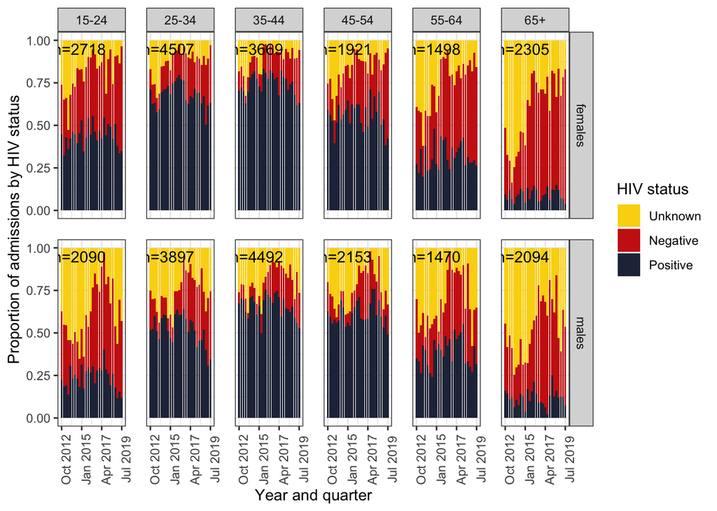

```r
color <- c(wes_palettes$Zissou1[1],wes_palettes$Zissou1[4],wes_palettes$Zissou1[5])

spine %>%
  mutate(hiv=as.character(hiv)) %>%
  mutate(hiv=replace_na(hiv,"Unknown")) %>%
  mutate(hiv=factor(hiv, levels=c("Unknown", "Negative","Positive"))) %>%
  mutate(q = group_indices(.,quarter)) %>%
  group_by(quarter) %>%
  mutate(number=n()) %>%
  ggplot() +
  geom_bar(aes(fill=hiv,x=quarter), position="fill") +
  geom_text(data=label_sum, aes(x=ymd("2014-10-01"), y=0.95,
                label=paste0("n=",sum, sep=""))) +
  facet_grid(sex ~ageg10) +
  scale_fill_manual(values=wes_palette("BottleRocket2")) +
    labs(
      #title="HIV status of adults admitted to QECH",
      #subtitle = "By quarter, and sex. n = total numer admissions between Q3.2012 to Q3.2019",
       x="Year and quarter",
       y="Proportion of admissions by HIV status",
       fill="HIV status") +
  scale_y_continuous() +
  scale_x_date(breaks=breaks1, date_labels = "%b %Y") +
  theme_bw() +
  theme(panel.spacing = unit(1, "lines"),
        axis.text.x=element_text(angle = 90))
```

```r
ggsave(here("figures/fig_1.pdf"), width = 9, height = 6, dpi=300)
```

## 3. Run imputation

Notes: This takes about ten minutes to run on my laptop. The file with imputation already done is in data folder, and loads at start of next chunk. To check / run imputation take out # (set here to avoid having to run imputation to knit file each time), and be careful about what file is loaded at start of next chunk.

25 imputations run as 25% missingness for HIV status. Assume HIV status MAR

- There were a very small number of people in dataset who have an ART status recorded but report HIV negative; I have set their ART status to NA.
- For everyone who had HIV status NA, but was imputed to be HIV positive, ART status is imputed as not on ART. This is because people who don’t know their HIV status (a reasonable proportion of people with it missing) won’t be on ART. ART status in people who are “truly” HIV positive but NAs in dataset is MNAR, and difficult to know how to make assumptions. This is a relatively small proportion of patients, and only relavent for part of the secondary objective.

```r
pred_matrix <- make.predictorMatrix(spine) #this is default predictor matrix - all values help impute all other values (apart from itself)
pred_matrix[,6] <- 0 # changing the art column to 0 so that ART status not used to impute anything else
pred_matrix[6,5] <- 0 # also asking HIV status not to be used to impute ART status, as I'm only going to try to impute art in those with HIV positive, so HIV status has no predictor value

# This is making a logical dataframe of what values should get imputed.  For most variables it's all NAs that get imputed, but for ART it's only those that are known HIV positive and NA
where <- spine %>%
  mutate(art=case_when(
    is.na(art)==FALSE ~ FALSE,
    is.na(art)==TRUE & hiv=="Positive" ~ TRUE,
    TRUE ~ FALSE
  )) %>%
  mutate(hiv=is.na(hiv)) %>%
  mutate(ageg10=is.na(ageg10)) %>%
  mutate(quarter=is.na(quarter)) %>%
  mutate(sex=is.na(sex)) %>%
  mutate(outcome=is.na(outcome))

# Then run the imputation --- this takes about 9 minutes to run -  have '#-ed' it by default to avoid running it by accident

######## IMPUTATION HERE!! ############
#################################3#####

# spine_mice <- mice(spine,m=25,maxit=5,seed=123,where=where,method="pmm",predictorMatrix=pred_matrix)

#usethis::use_data(spine_mice, overwrite = TRUE)

####################################
###################################
```

Load imputed dataset, extract completed data from mids object, group by HIV status to get proportions / counts and merge with census data for population denomiator.

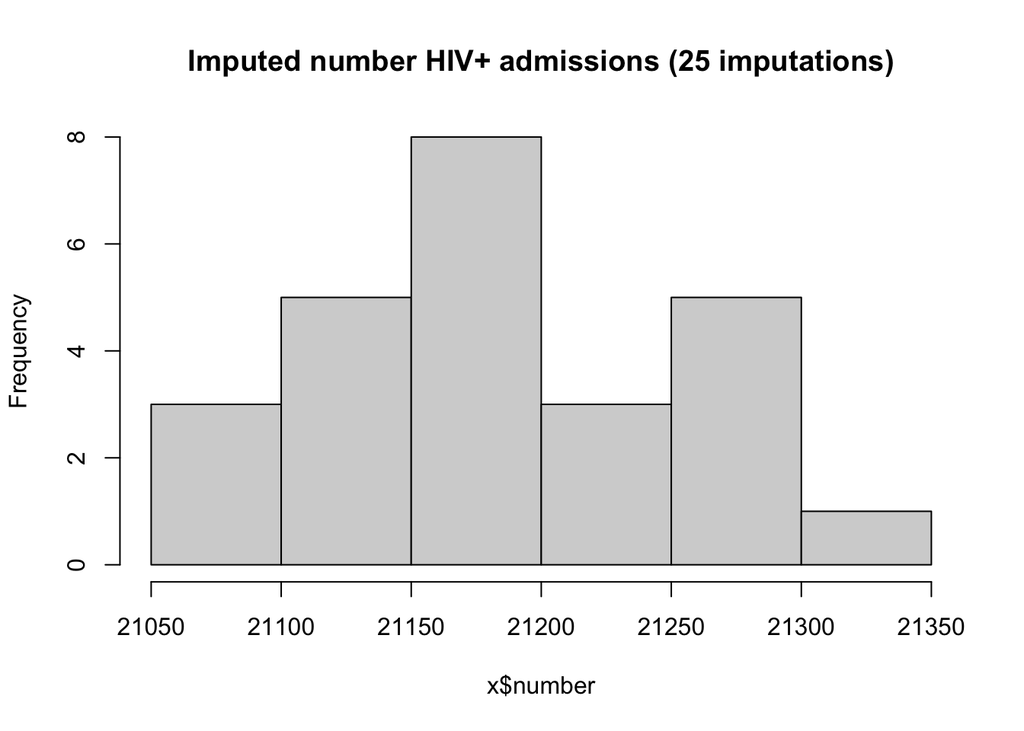

```r
load(here("data-raw", "spine_mice.rda"))  #NB. loads from data folder; can recreate using code above
#summary(spine_mice)

#get the imputed datasets in long format
spine_imp <- mice::complete(spine_mice, action="long", include = FALSE)

# checking the number of HIV positive admissions in each imputation
x <- spine_imp %>% group_by(.imp) %>% filter(hiv=="Positive") %>% mutate(number=n()) %>% dplyr::select(.imp,number) %>% unique()
hist(x$number, main="Imputed number HIV+ admissions (25 imputations)")
```

```r
#summarise the data sets by group to get the counts
spine_imp_gp <- spine_imp %>%
  group_by(.imp, quarter, ageg10, sex, hiv) %>% #NB. not interested in 'outcome' for this bit, so not grouped by this
  summarise(n_imputed=n())
#merge the denominators to the imputed grouped datasets
both_imp_gp <- left_join(spine_imp_gp, cens_edit) %>%
  mutate(n = case_when(is.na(n_imputed) ~ 0L,
                       TRUE ~ n_imputed)) %>%  # 'n' is now from n_imputed
  mutate(inc = (n/pop) * 100000) %>%
  ungroup() %>%
  mutate(q = group_indices(.,quarter))
usethis::use_data(both_imp_gp, overwrite = TRUE) # saving data
```

```
## ✓ Setting active project to '/Users/rachaelburke/Documents/2020_spine/2020_hivhospital'
```

```
## ✓ Saving 'both_imp_gp' to 'data/both_imp_gp.rda'
```

```
## ● Document your data (see 'https://r-pkgs.org/data.html')
```

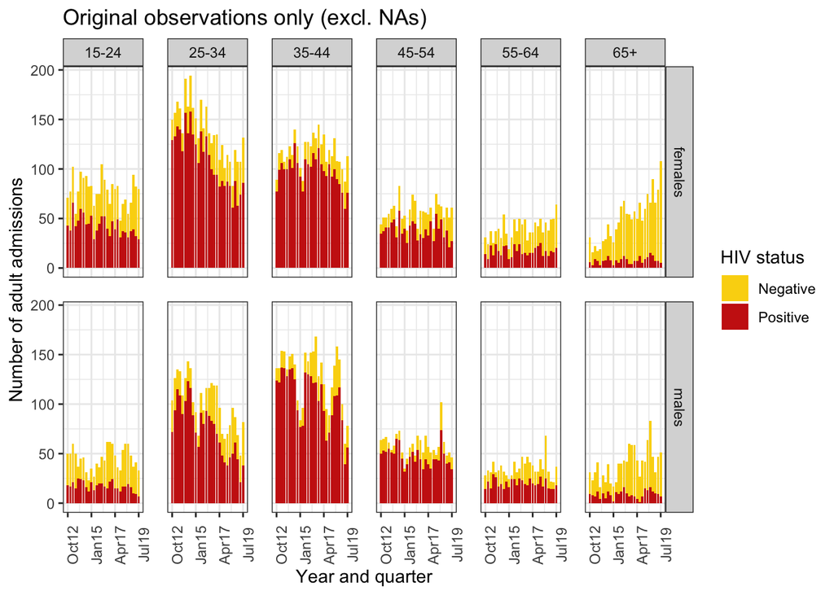

```r
## Check imputed data (one of the imputations) by graphing original data and imputed 'observations'.
spine_imp2 <- mice::complete(spine_mice, action="long", include = TRUE)
spine_imp2$hiv_recorded <- cci(spine$hiv)
spine_imp2 <- spine_imp2 %>% filter(.imp==12) # take one of imputations

original_obs <- spine_imp2 %>%
  filter(hiv_recorded==TRUE) %>% # these are the ones with HIV wasn't missing
  group_by(quarter, ageg10, sex, hiv) %>%
  summarise(n=n()) %>%
  ungroup() %>%
  mutate(q = group_indices(.,quarter))
original_obs %>%
  mutate(HIV=as.character(hiv)) %>%
  mutate(HIV=replace_na(HIV,"Unknown / Missing")) %>%
  mutate(HIV=factor(HIV, levels=c("Unknown / Missing", "Negative","Positive"))) %>%
  ggplot() +
  geom_bar(aes(fill=HIV,x=quarter, y=n), stat="identity") +
  facet_grid(sex ~ageg10) +
  scale_fill_manual(values=wes_palette("BottleRocket2",3)) +
    labs(
      title = "Original observations only (excl. NAs)",
       x="Year and quarter",
       y="Number of adult admissions",
      fill="HIV status") +
  scale_y_continuous() +
  scale_x_date(breaks=breaks1, date_labels = "%b%y ") +
  theme_bw() +
  theme(panel.spacing = unit(1, "lines"),
        axis.text.x=element_text(angle = 90))
```

```r
imputed_obs <- spine_imp2 %>%
  filter(hiv_recorded==FALSE) %>% # these are the ones with HIV wasn't missing
  group_by(quarter, ageg10, sex, hiv) %>%
  summarise(n=n()) %>%
  ungroup() %>%
  mutate(q = group_indices(.,quarter))
```

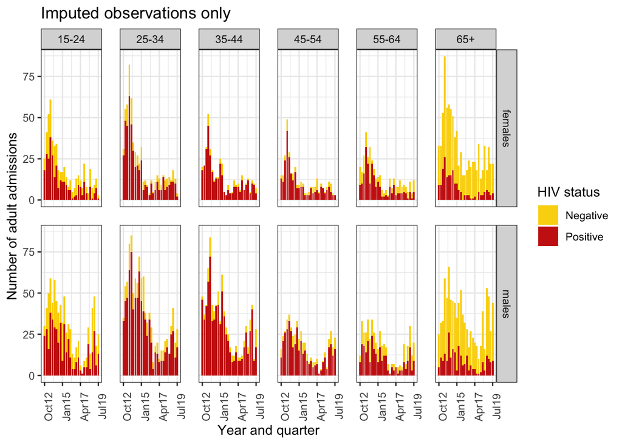

```r
imputed_obs %>%
  mutate(HIV=as.character(hiv)) %>%
  mutate(HIV=replace_na(HIV,"Unknown / Missing")) %>%
  mutate(HIV=factor(HIV, levels=c("Unknown / Missing", "Negative","Positive"))) %>%
  ggplot() +
  geom_bar(aes(fill=HIV,x=quarter, y=n), stat="identity") +
  facet_grid(sex ~ageg10) +
  scale_fill_manual(values=wes_palette("BottleRocket2",3)) +
    labs(
      title = "Imputed observations only",
       x="Year and quarter",
       y="Number of adult admissions",
      fill="HIV status") +
  ylim(0,200) +
  scale_y_continuous() +
  scale_x_date(breaks=breaks1, date_labels = "%b%y ") +
  theme_bw() +
  theme(panel.spacing = unit(1, "lines"),
        axis.text.x=element_text(angle = 90))
```

```r
# These two graphs looks fairly similar
```

## 4. Create the model for incidence of HIV positive neg binomial 3 splines

Creates 25 different models (one for each imputed data frame)

```r
#nest by imputed grouped dataset
by_imp <- both_imp_gp %>%
  ungroup() %>%
  nest_by(.imp)

# Fit the model for each imputed grouped dataset.  For HIV positive admissions.
model_imp_n3 <- by_imp %>% mutate(model = list(glm.nb(n ~ ns(q, knots = 3)*ageg10*sex, data = data %>% filter(hiv=="Positive"),offset(log(pop)))))

# Same model for HIV negative admissions
model_neg <- both_imp_gp %>% ungroup() %>% filter(hiv=="Negative") %>% nest_by(.imp) %>% mutate(model = list(glm.nb(n ~ ns(q, knots = 3)*ageg10*sex, data = data, offset(log(pop)))))
```

## 5. Get the predictions from the model

Using Amelia mi.meld tools and Andrew Heiss’ approach https://gist.github.com/andrewheiss/a3134085e92c6607db39c5b14e1b879e – slightly modified

Build models seperately for incidence of both HIV positive and HIV negative admissions.

```r
model2pred_imp <- function(df,m,var1,var2,var3,x){

  scaffold_df <- both_imp_gp %>%
    filter(hiv==x) %>% # HIV status
    ungroup() %>%
    dplyr::select(-.imp) %>%
    expand(q,ageg10,sex)

  df2 <- df %>% filter(hiv==x)

  predict_melded <- tibble(models = m$model) %>%
    ungroup() %>%
    mutate(m = 1:n(),
         fitted = models %>% map(~ augment(., newdata = scaffold_df, se_fit=TRUE))) %>% # this gives fit from each model
  unnest(fitted) %>%
  dplyr::select(m,q,ageg10,sex,.fitted,.se.fit) %>% # added in select to get rid of model df that was slowwing everything down....
  group_by(q,ageg10,sex) %>%  # Group by each of the variables that you vary
  nest(data= c(m, .fitted, .se.fit))  %>% # need to add 'm' here, otherwise nothing to meld over
  mutate(fitted_melded = data %>% map(~ meld_predictions(.))) %>%  #using the meld_predictions function I just defined
  unnest(fitted_melded) %>%
    mutate(n_est = exp(.fitted)) %>%
    mutate(n_low =exp(.fitted - 1.96*.se.fit)) %>% #keep on response scale here
    mutate(n_high = exp(.fitted + 1.96*.se.fit))%>%
  left_join(df2) %>%
  mutate(inc=exp((.fitted - log(pop)) + log(100000))) %>% #incidence per 100,000
  mutate(inc_low=exp(((.fitted - 1.96*.se.fit) - log(pop)) + log(100000))) %>%
  mutate(inc_high=exp(((.fitted + 1.96*.se.fit) - log(pop)) + log(100000))) %>%
    ungroup()
}

# Model predicted outputs
out_n3 <- model2pred_imp(both_imp_gp,model_imp_n3,q,ageg10,sex,"Positive")  # so this has 25 imputed dataframes, but inc, n_est and their CIs are exactly the same now across all imputed data frames
out_neg <- model2pred_imp(both_imp_gp,model_neg,q,ageg10,sex,"Negative")
```

## 6. Plot the predictions

Dots are from imputed dataset 12, model predictions are from melding across all dataframes.

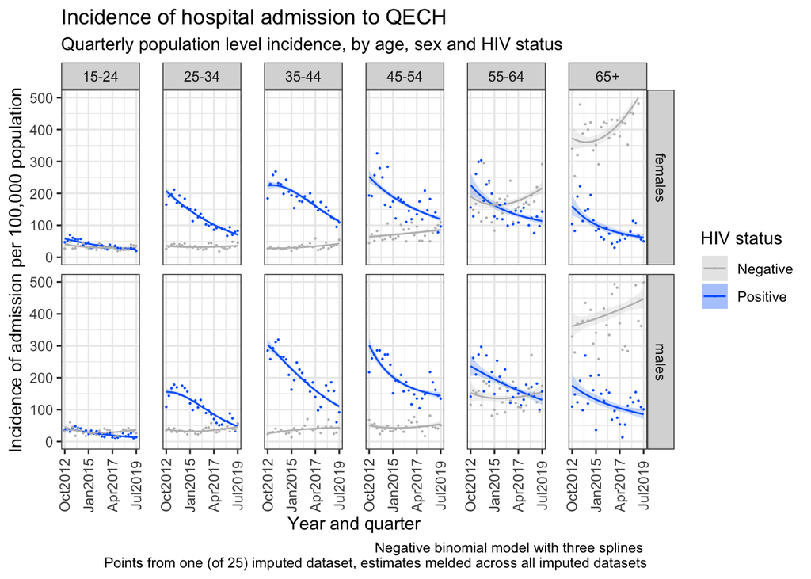

```r
ggplot() +
  geom_line(data=out_n3, aes(x = quarter, y = inc, color=hiv)) +
  geom_ribbon(data=out_n3, aes(x=quarter, ymin = inc_low, ymax = inc_high, fill=hiv), alpha = 0.2) +
  geom_line(data=out_neg, aes(x = quarter, y = inc, color=hiv)) +
  geom_ribbon(data=out_neg, aes(x=quarter, ymin = inc_low, ymax = inc_high,fill=hiv), alpha = 0.2) +
  geom_point(data=both_imp_gp %>% filter(.imp==12) %>% filter(hiv=="Positive"), aes(x=quarter, y=((n_imputed/pop)*100000), color=hiv),size=0.1) +
  geom_point(data=both_imp_gp %>% filter(.imp==12) %>% filter(hiv=="Negative"), aes(x=quarter, y=((n_imputed/pop)*100000), color=hiv),size=0.1) +
  facet_grid(sex ~ ageg10) +
  scale_x_date(breaks=breaks1, date_labels = "%b%Y ") +
  scale_y_continuous(limits=c(0,500)) +
  scale_color_manual(values=c("Positive"="#0066FF","Negative" = "grey")) +
  scale_fill_manual(values=c("Positive"="#0066FF","Negative" = "grey")) +
  labs(
    title = "Incidence of hospital admission to QECH",
    subtitle="Quarterly population level incidence, by age, sex and HIV status",
    caption="Negative binomial model with three splines \n Points from one (of 25) imputed dataset, estimates melded across all imputed datasets",
    fill="HIV status",
    color="HIV status") +
  ylab("Incidence of admission per 100,000 population") +
  xlab("Year and quarter") +
    theme_bw() %+replace%
  theme(panel.spacing.x=unit(0.5, "cm"),
        axis.text.x=element_text(angle = 90))
```

```r
ggsave(here("figures/fig_2.pdf"), width = 9, height = 6, dpi=300)
```

## 7. Determine the number of admissions “averted” and CI in imputed datasets

“Averted” = number fewer admissions than would have been if Q3.2012 incidence stayed same. Note ‘Averted’ used as a shorthand verb, not assuming causation.

CI using parametric bootstrapping

Set up functions

```r
# Point estimate from 'real' data on the number of admissions averted (singling out .fitted on response scale, as in next change this is replaced by normal distribution to sample from)
avert_est <- function(df){
  df <-
    {if (".imp" %in% names(df)==TRUE) df %>% filter(.imp==1) %>% dplyr::select(-.imp) else df} #NB. Each .imp contains exactly the same (melded) estimates of .fitted and .se.fitted (they remained nested in 25 dfs). This "if" bit is here so same function can be used in non-imputed dataframes.
    worst <- df %>% filter(quarter==dmy("01 Oct 2012")) %>%
    mutate(q32012_inc = exp((
      .fitted
      - log(pop)))) %>%
    right_join(df) %>%
    group_by(ageg10,sex,hiv) %>% fill(q32012_inc) %>% ungroup() %>%
    mutate(worst_est= q32012_inc * pop) %>%
    mutate(actual_est = exp(  #at the moment, this is redundant as already have exp(fitted) in df, but putting here for completeness when come to bootstrap estimate
    .fitted
    )) %>%
    mutate(avert_est = worst_est - actual_est)
}

avert_all_data <- function(df,lab){
  worst <- df %>% dplyr::select(worst_est) %>% sum()
  actual <- df%>% dplyr::select(actual_est) %>% sum()
  averted <- worst - actual
  averted_p <- averted/worst
  tribble(~"NA_handling", ~"worst", ~"actual", ~"averted",~"averted_p",
          lab, worst, actual, averted, averted_p)
}

# purr / pmap is from https://stackoverflow.com/questions/46207434/using-rnorm-for-a-dataframe

# A bootstrap-able function, where .fitted is changed to a normal distribution with mean .fitted and st dev .se fitted.
# As must all be in one function to bootstrap, this combines 'avert_est' and 'avert_all_data'

avert_boot <- function(df){ # This creates estimates for each agegroup and sex category, sampling from normal distrubtion (on response scale) with mean = point estimate fitted model and sd = st error of fit, then exponentiated to link scale.
  df <-
    {if (".imp" %in% names(df)==TRUE) df %>% filter(.imp==1) else df} #NB. Each .imp contains exactly the same (melded) estimates of .fitted and .se.fitted (they remained nested in 25 dfs)
  DF <- df %>% filter(quarter==dmy("01 Oct 2012")) %>%
    mutate(q32012_inc = exp((
      as.numeric(pmap(list(.fitted,.se.fit), function(mu, sd) rnorm(1, mu, sd)))  # changed .fitted (point est of number admissions) to function of normal distrubctuion with mean .fitted and st dev se.fitted.  This should be bootstrapp-able.
      - log(pop)))) %>% # minus logs to determine population incidence
    right_join(df,by = c("q", "sex", "ageg10", ".fitted", ".se.fit", "n_est", "n_low", "n_high", "quarter", "pop", "n", "hiv", "inc", "inc_low", "inc_high")) %>%
    group_by(ageg10,sex,hiv) %>% fill(q32012_inc) %>% ungroup() %>%
    mutate(worst_est= q32012_inc * pop) %>%
    mutate(actual_est = exp(
      as.numeric(pmap(list(.fitted,.se.fit), function(mu, sd) rnorm(1, mu, sd)))
    )) %>%
    mutate(avert_est = worst_est - actual_est) %>%
    mutate(avert_p_est = avert_est / worst_est)
}

boot_fx <- function(df){
  df2 <- avert_boot(df)
  worst <- df2 %>% dplyr::select(worst_est) %>% sum()
  actual <- df2 %>% dplyr::select(actual_est) %>% sum()
  avert <- df2 %>% dplyr::select(avert_est) %>% sum()
  avert_p <- avert/worst
  c(worst, actual, avert,avert_p)
}

boot_fx_byageandsex <- function(df){
  df2 <- avert_boot(df) %>% dplyr::arrange(ageg10,sex)
  group_vars <- df2 %>% group_by(ageg10,sex) %>%
    summarise_at(vars(worst_est,actual_est,avert_est),funs(sum)) %>%
    dplyr::select(ageg10,sex)
  df2 %>% group_by(ageg10,sex) %>%
    summarise_at(vars(worst_est,actual_est,avert_est),funs(sum)) %>% ungroup() %>%
        mutate(avert_p=avert_est/worst_est) %>%
    dplyr::select(worst_est, actual_est, avert_est,avert_p) %>% as.matrix()
}

group_vars <- function(df){
  df2 <- avert_boot(df) %>% dplyr::arrange(ageg10,sex)
  group_vars <- df2 %>% group_by(ageg10,sex) %>%
    summarise_at(vars(worst_est,actual_est,avert_est),funs(sum)) %>%
    dplyr::select(ageg10,sex)
  group_vars
  }
```

Run for imputed dataset

```r
# run function once to check - these should be fairly similar
avert_all_data(avert_est(out_n3),"imp") #df of output of point estimates
```

```
## # A tibble: 1 x 5
##   NA_handling  worst actual averted averted_p
##   <chr>        <dbl>  <dbl>   <dbl>     <dbl>
## 1 imp         31988. 21170.  10818.     0.338
```

```r
boot_fx(out_n3) # matrix of one boot rep of estimates
```

```
## [1] 3.161137e+04 2.118267e+04 1.042870e+04 3.299034e-01
```

```r
# now run function 1000 times and plot
boot_n3 <- boot(out_n3,boot_fx,R=1000,sim="parametric") #1000 iterations (takes about 90 secs to run)
sd_n3 <- c(sd(boot_n3$t[,1]),sd(boot_n3$t[,2]),sd(boot_n3$t[,3]),sd(boot_n3$t[,4])) # boot command output is a vector of estimate for worst / actual / averted; so boot output is a matrix.  Calculating st deviation for each column of matrix
sd_n3[[1]]
```

```
## [1] 377.4113
```

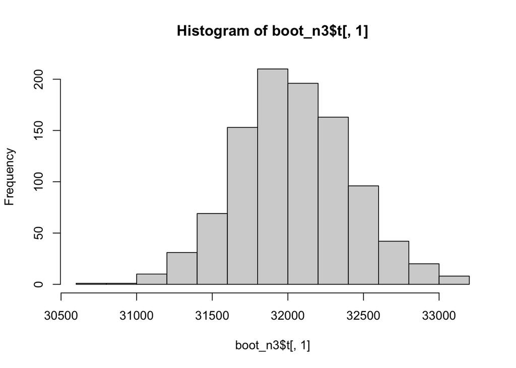

```r
hist(boot_n3$t[,1]) # check histogram output
```

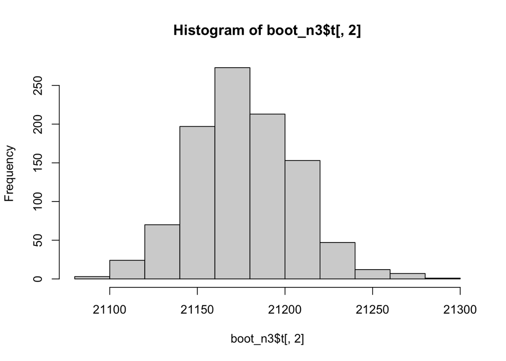

```r
hist(boot_n3$t[,2])
```

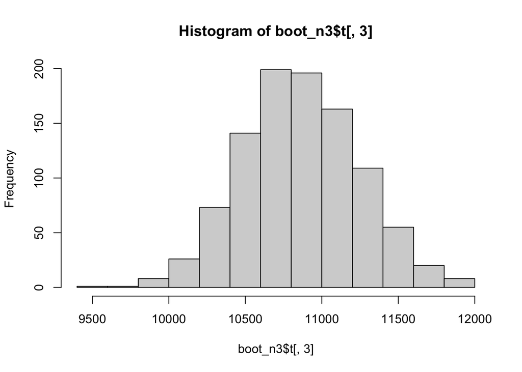

```r
hist(boot_n3$t[,3])
```

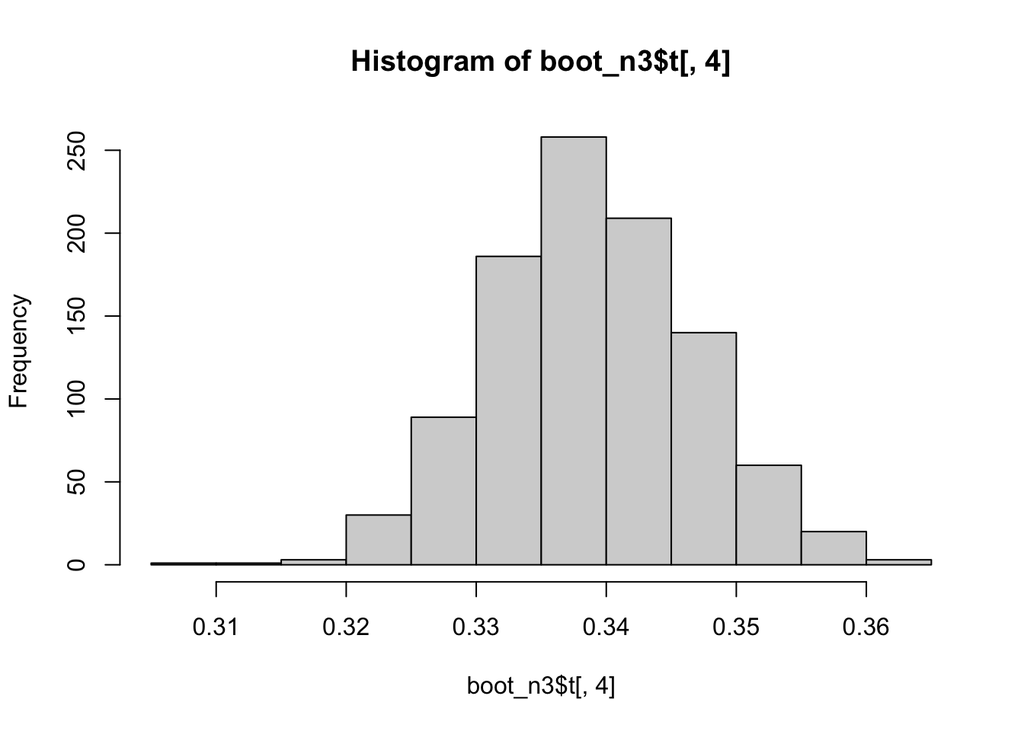

```r
hist(boot_n3$t[,4])
```

```r
## Make into a table
avert_table <- function(df,sd,lab) {
  avert_all_data(avert_est(df),lab) %>%
  mutate(worst.hi = worst + 1.96*(sd[[1]])) %>%
  mutate(worst.lo = worst - 1.96*(sd[[1]])) %>%
  mutate(actual.hi = actual + 1.96*(sd[[2]])) %>%
  mutate(actual.lo = actual - 1.96*(sd[[2]])) %>%
  mutate(avert.hi = averted + 1.96*(sd[[3]])) %>%
  mutate(avert.lo = averted - 1.96*(sd[[3]])) %>%
  mutate(avertp.hi = averted_p + 1.96*(sd[[4]])) %>%
  mutate(avertp.lo = averted_p - 1.96*(sd[[4]])) %>%
  mutate(worst_ = paste0(round(worst,digits=0)," (",round(worst.lo,digits=0)," to ",round(worst.hi, digits=0),")")) %>%
  mutate(actual_ = paste0(round(actual,digits=0)," (",round(actual.lo,digits=0)," to ",round(actual.hi, digits=0),")")) %>%
  mutate(averted_ = paste0(round(averted,digits=0)," (",round(avert.lo,digits=0)," to ",round(avert.hi, digits=0),")")) %>%
  mutate(avertedp_ = paste0(round(averted_p,digits=3)," (",round(avertp.lo,digits=3)," to ",round(avertp.hi, digits=3),")"))
}

imp <- avert_table(out_n3,sd_n3,"imp")
```

## 8. Sensitivity analysis for estimates of admissions ‘averted’ (Table 2 at the end of this)

Create grouped data and number admissions for various assumptions about HIV status (negative, positive, postitive_and_unknown, negative_and_unknown) from spine (individual) dataset and census.

Then filter this dataset for desired sensitivity analyses

```r
# Construct grouped data from spine and census dataset

spine_gp_all_orig <- spine %>%  ## grouped, all admissions
  group_by(quarter,ageg10,sex) %>%
  summarise(n=n(), .groups="keep") %>%
  mutate(hiv="all") %>%
  ungroup()

spine_gp_hivpos_orig <- spine %>% # grouped, HIV pos
  filter(hiv=="Positive") %>%
  group_by(quarter,ageg10,sex) %>%
  summarise(n=n(), .groups="keep") %>%
  mutate(hiv="pos") %>%
  ungroup()

spine_gp_hivneg_orig <- spine %>% # grouped, HIV neg
  filter(hiv=="Negative") %>%
  group_by(quarter,ageg10,sex) %>%
  summarise(n=n(), .groups="keep") %>%
  mutate(hiv="neg") %>%
  ungroup()

spine_gp_hivunk_orig <- spine %>% # grouped, HIV unknown
  filter(is.na(hiv)) %>%
  group_by(quarter,ageg10,sex) %>%
  summarise(n=n(),.groups="keep") %>%
  mutate(hiv="unk") %>%
  ungroup()

spine_gp_hivposandunk_orig <- spine %>%  # grouped, HIV pos and unknown grouped together
  filter(hiv=="Positive" | is.na(hiv)) %>%
  group_by(quarter,ageg10,sex) %>%
  summarise(n=n(),.groups="keep") %>%
  mutate(hiv="posandunk") %>%
  ungroup()

spine_gp_orig <- rbind(spine_gp_all_orig, spine_gp_hivpos_orig, spine_gp_hivneg_orig,spine_gp_hivunk_orig,spine_gp_hivposandunk_orig)

both_orig <- left_join(cens_edit,spine_gp_orig) %>%  # add census denomiators
    mutate(n = case_when(is.na(n) ~ 0L,
                       TRUE ~ n)) %>%
  mutate(inc = (n/pop) * 100000) %>%
  ungroup() %>%
    mutate(q = group_indices(.,quarter))
model2pred_orig <- function(df,m){
  df %>%
    data_grid(q, sex, ageg10, .model = m) %>%
    augment(m, newdata = ., type.predict="link", se_fit=TRUE) %>%
    mutate(n_est = exp(.fitted)) %>%
    mutate(n_low =exp(.fitted - 1.96*.se.fit)) %>%
    mutate(n_high = exp(.fitted + 1.96*.se.fit))%>%
     left_join(df) %>%
  mutate(inc=exp((.fitted - log(pop)) + log(100000))) %>% #incidence per 100,000
  mutate(inc_low=exp(((.fitted - 1.96*.se.fit) - log(pop)) + log(100000))) %>%
  mutate(inc_high=exp(((.fitted + 1.96*.se.fit) - log(pop)) + log(100000))) %>%
    ungroup()
}
```

And now run for non-imputed datasets

```r
both_orig_hivpos <- both_orig %>% filter(hiv=="pos")
pos_only <- glm.nb(n ~ ns(q, knots=3)*sex*ageg10, offset(log(pop)), data=both_orig_hivpos)
out_pos <- model2pred_orig(both_orig_hivpos,pos_only)
# run function once to check - these should be fairly similar
avert_all_data(avert_est(out_pos),"Unknowns_neg") #df of output of point estimates
```

```
## # A tibble: 1 x 5
##   NA_handling   worst actual averted averted_p
##   <chr>         <dbl>  <dbl>   <dbl>     <dbl>
## 1 Unknowns_neg 20262. 16408.   3854.     0.190
```

```r
boot_fx(out_pos) # matrix of one boot rep of estimates
```

```
## [1] 2.032657e+04 1.641504e+04 3.911537e+03 1.924347e-01
```

```r
# now run function 1000 times and plot
boot_pos <- boot(out_pos,boot_fx,R=1000,sim="parametric") #1000 iterations (takes about 90 secs to run)
sd_pos <- c(sd(boot_pos$t[,1]),sd(boot_pos$t[,2]),sd(boot_pos$t[,3]),sd(boot_pos$t[,4]))
sd_pos[[1]]
```

```
## [1] 196.4757
```

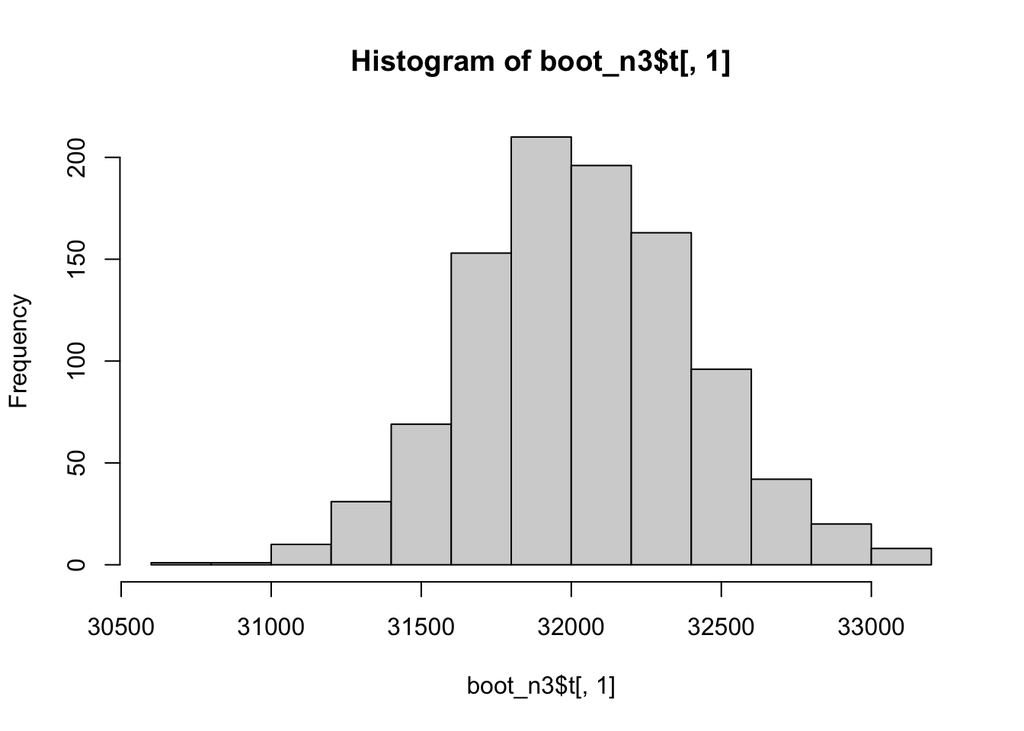

```r
hist(boot_n3$t[,1]) # check histogram output
```

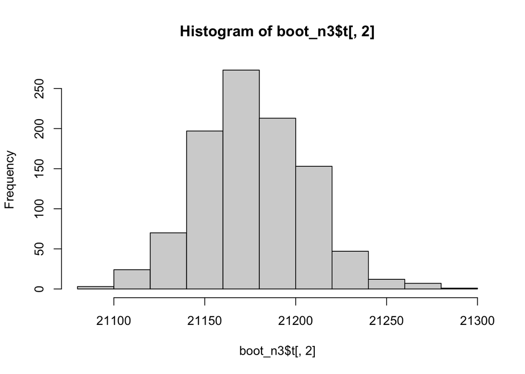

```r
hist(boot_n3$t[,2])
```

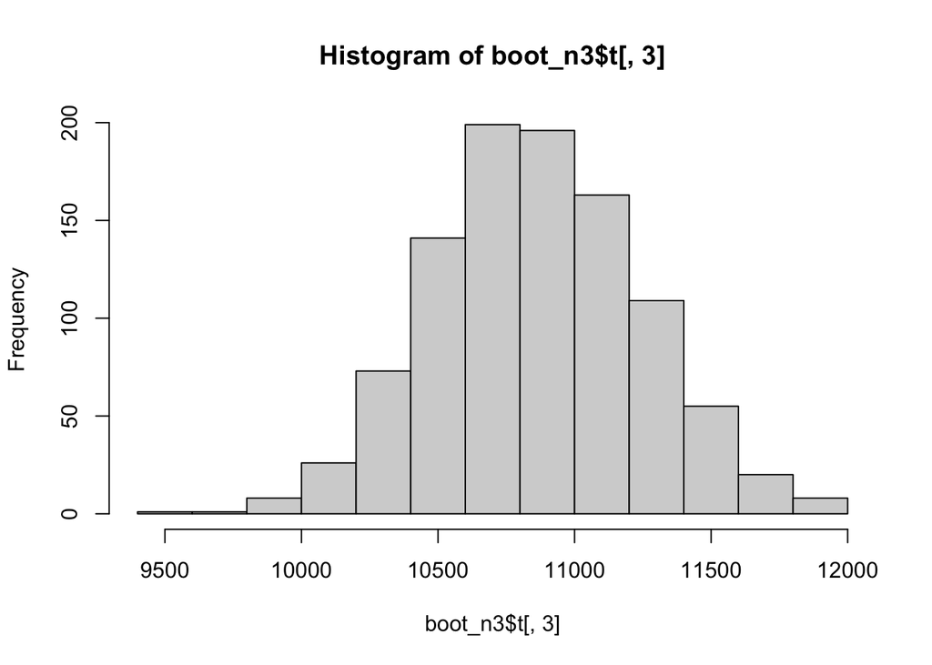

```r
hist(boot_n3$t[,3])
```

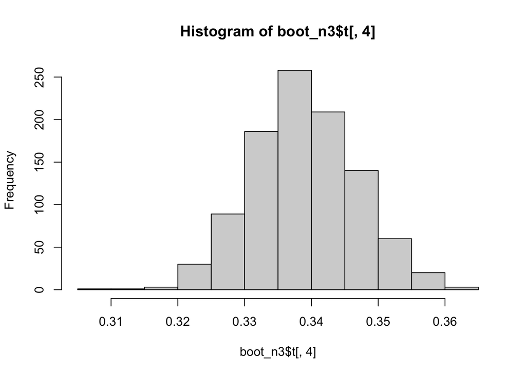

```r
hist(boot_n3$t[,4])
```

```r
## Make into a table
na_neg <- avert_table(out_pos,sd_pos,"Unknowns_neg")
both_orig_hivposunk <-  both_orig %>% filter(hiv=="posandunk")
posandunk <- glm.nb(n ~ ns(q, knots=3)*sex*ageg10, offset(log(pop)), data=both_orig_hivposunk)
out_unk <- model2pred_orig(both_orig_hivposunk,posandunk)
# run function once to check - point estimates and bootstrap est (1 rep) should be fairly similar
avert_all_data(avert_est(out_unk),"Unknowns_pos") #df of output of point estimates
```

```
## # A tibble: 1 x 5
##   NA_handling   worst actual averted averted_p
##   <chr>         <dbl>  <dbl>   <dbl>     <dbl>
## 1 Unknowns_pos 38270. 24404.  13865.     0.362
```

```r
boot_fx(out_unk) # matrix of one boot rep of estimates
```

```
## [1] 3.854203e+04 2.440496e+04 1.413707e+04 3.667963e-01
```

```r
# now run function 1000 times and plot
boot_unk <- boot(out_unk,boot_fx,R=1000,sim="parametric") #1000 iterations (takes about 90 secs to run)
sd_unk <- c(sd(boot_unk$t[,1]),sd(boot_unk$t[,2]),sd(boot_unk$t[,3]),sd(boot_unk$t[,4]))
sd_pos[[1]]
```

```
## [1] 196.4757
```

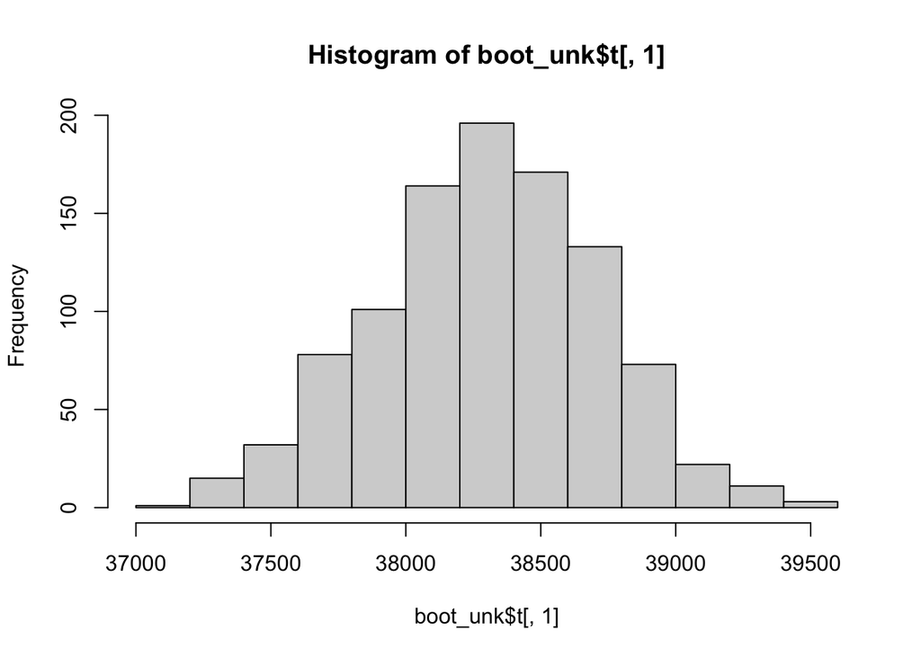

```r
hist(boot_unk$t[,1]) # check histogram output
```

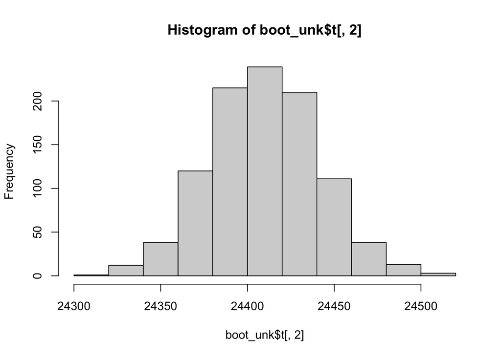

```r
hist(boot_unk$t[,2])
```

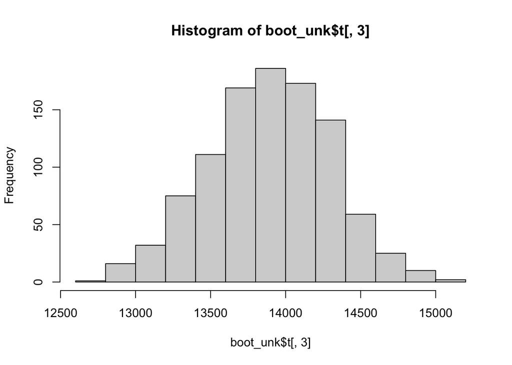

```r
hist(boot_unk$t[,3])
```

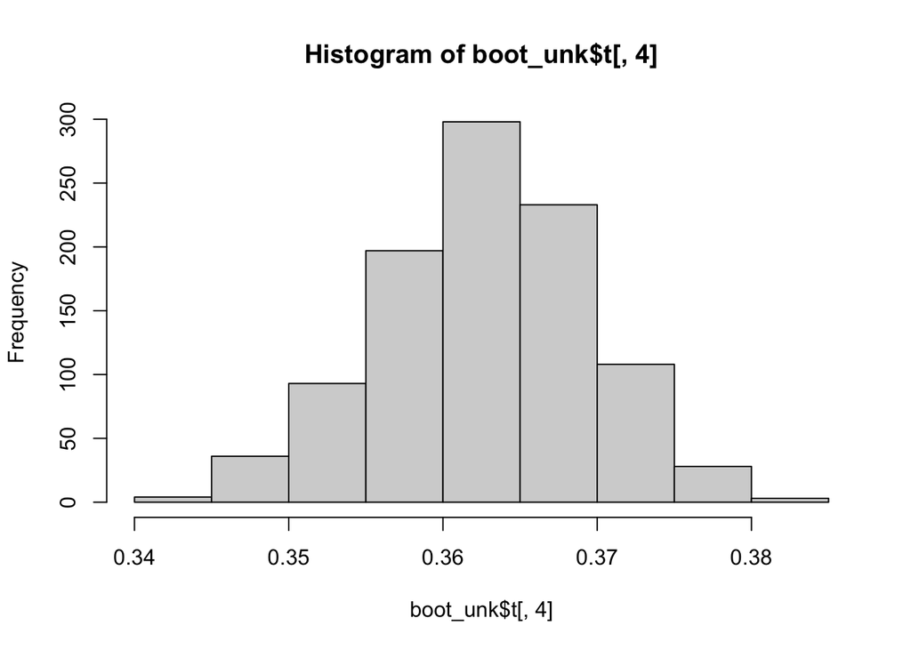

```r
hist(boot_unk$t[,4])
```

```r
## Make into a table
na_pos <- avert_table(out_unk,sd_unk,"Unknowns_pos")
```

Construct table 2

```r
imp %>% rbind(na_pos) %>% rbind(na_neg) %>% dplyr::select(NA_handling, worst_, actual_, averted_, avertedp_) %>% gt()
```

| NA_handling | worst_ | actual_ | averted_ | avertedp_ |
| --- | --- | --- | --- | --- |
| imp | 31988 (31248 to 32727) | 21170 (21110 to 21229) | 10818 (10076 to 11560) | 0.338 (0.323 to 0.354) |
| Unknowns_pos | 38270 (37467 to 39072) | 24404 (24343 to 24465) | 13865 (13065 to 14666) | 0.362 (0.349 to 0.376) |
| Unknowns_neg | 20262 (19876 to 20647) | 16408 (16371 to 16444) | 3854 (3467 to 4241) | 0.19 (0.175 to 0.206) |

We can sense check these with the actual ‘actual’ numbers (not model estimates) for where we make assumptions about NAs. Also confirms that model fits reasonably well if model predicted numbers v. close to actual numbers (neg binomial, 3 splines)

```r
spine %>% filter(hiv=="Positive") %>% nrow()
```

```
## [1] 16408
```

```r
spine %>% filter(hiv=="Positive" | is.na(hiv)==TRUE) %>% nrow()
```

```
## [1] 24404
```

## 9. Is the rate of change different by age and sex?

Estimate marginal trends https://stats.idre.ucla.edu/r/seminars/interactions-r/

```r
## Model with imputation
int_df2 <- model_imp_n3 %>%
  ungroup() %>%
  filter(.imp == 12) %>%
  dplyr::select(model,data) # not sure why I can't just unnest....
n3_model <- int_df2[[1]][[1]]

n3_model
```

```
##
## Call:  glm.nb(formula = n ~ ns(q, knots = 3) * ageg10 * sex, data = data %>%
##     filter(hiv == "Positive"), weights = offset(log(pop)), init.theta = 47.6567532,
##     link = log)
##
## Coefficients:
##                         (Intercept)                    ns(q, knots = 3)1
##                             4.22338                             -0.67484
##                   ns(q, knots = 3)2                             ageg10.L
##                            -0.57803                             -1.36154
##                            ageg10.Q                             ageg10.C
##                            -0.70433                              0.65685
##                            ageg10^4                             ageg10^5
##                            -0.19319                              0.09014
##                            sexmales           ns(q, knots = 3)1:ageg10.L
##                            -0.01094                             -0.24843
##          ns(q, knots = 3)2:ageg10.L           ns(q, knots = 3)1:ageg10.Q
##                             0.19220                             -0.67160
##          ns(q, knots = 3)2:ageg10.Q           ns(q, knots = 3)1:ageg10.C
##                            -0.16721                             -0.07920
##          ns(q, knots = 3)2:ageg10.C           ns(q, knots = 3)1:ageg10^4
##                            -0.11035                              0.25270
##          ns(q, knots = 3)2:ageg10^4           ns(q, knots = 3)1:ageg10^5
##                             0.21422                             -0.44098
##          ns(q, knots = 3)2:ageg10^5           ns(q, knots = 3)1:sexmales
##                            -0.14153                              0.08268
##          ns(q, knots = 3)2:sexmales                    ageg10.L:sexmales
##                            -0.02683                              0.21115
##                   ageg10.Q:sexmales                    ageg10.C:sexmales
##                            -0.62848                             -0.03028
##                   ageg10^4:sexmales                    ageg10^5:sexmales
##                             0.27623                             -0.17441
## ns(q, knots = 3)1:ageg10.L:sexmales  ns(q, knots = 3)2:ageg10.L:sexmales
##                             0.66381                              0.44142
## ns(q, knots = 3)1:ageg10.Q:sexmales  ns(q, knots = 3)2:ageg10.Q:sexmales
##                             0.65436                              0.21691
## ns(q, knots = 3)1:ageg10.C:sexmales  ns(q, knots = 3)2:ageg10.C:sexmales
##                             0.19558                             -0.18276
## ns(q, knots = 3)1:ageg10^4:sexmales  ns(q, knots = 3)2:ageg10^4:sexmales
##                            -0.38644                              0.14076
## ns(q, knots = 3)1:ageg10^5:sexmales  ns(q, knots = 3)2:ageg10^5:sexmales
##                             0.28517                              0.14752
##
## Degrees of Freedom: 335 Total (i.e. Null);  300 Residual
## Null Deviance:       52150
## Residual Deviance: 4020  AIC: 27420
```

```r
emtrends(n3_model, pairwise ~ ageg10|sex, var="q", data=int_df2[[2]][[1]], transform="response")
```

```
## $emtrends
## sex = females:
##  ageg10 q.trend     SE  df asymp.LCL asymp.UCL
##  15-24   -1.462 0.0868 Inf    -1.633   -1.2922
##  25-34   -4.332 0.1851 Inf    -4.695   -3.9690
##  35-44   -1.940 0.1649 Inf    -2.264   -1.6173
##  45-54   -0.880 0.0824 Inf    -1.041   -0.7180
##  55-64   -0.511 0.0543 Inf    -0.617   -0.4044
##  65+     -0.300 0.0360 Inf    -0.370   -0.2291
##
## sex = males:
##  ageg10 q.trend     SE  df asymp.LCL asymp.UCL
##  15-24   -1.025 0.0633 Inf    -1.149   -0.9012
##  25-34   -5.282 0.1819 Inf    -5.638   -4.9250
##  35-44   -3.684 0.1944 Inf    -4.065   -3.3024
##  45-54   -0.753 0.0918 Inf    -0.933   -0.5732
##  55-64   -0.536 0.0617 Inf    -0.657   -0.4147
##  65+     -0.171 0.0412 Inf    -0.252   -0.0905
##
## Confidence level used: 0.95
##
## $contrasts
## sex = females:
##  contrast          estimate     SE  df z.ratio p.value
##  (15-24) - (25-34)    2.869 0.2045 Inf  14.034 <.0001
##  (15-24) - (35-44)    0.478 0.1863 Inf   2.566 0.1058
##  (15-24) - (45-54)   -0.583 0.1197 Inf  -4.868 <.0001
##  (15-24) - (55-64)   -0.952 0.1024 Inf  -9.292 <.0001
##  (15-24) - (65+)     -1.163 0.0940 Inf -12.371 <.0001
##  (25-34) - (35-44)   -2.391 0.2479 Inf  -9.647 <.0001
##  (25-34) - (45-54)   -3.452 0.2026 Inf -17.037 <.0001
##  (25-34) - (55-64)   -3.821 0.1929 Inf -19.807 <.0001
##  (25-34) - (65+)     -4.032 0.1886 Inf -21.382 <.0001
##  (35-44) - (45-54)   -1.061 0.1843 Inf  -5.755 <.0001
##  (35-44) - (55-64)   -1.430 0.1736 Inf  -8.236 <.0001
##  (35-44) - (65+)     -1.641 0.1688 Inf  -9.723 <.0001
##  (45-54) - (55-64)   -0.369 0.0987 Inf  -3.736 0.0026
##  (45-54) - (65+)     -0.580 0.0899 Inf  -6.448 <.0001
##  (55-64) - (65+)     -0.211 0.0651 Inf  -3.243 0.0150
##
## sex = males:
##  contrast          estimate     SE  df z.ratio p.value
##  (15-24) - (25-34)    4.256 0.1926 Inf  22.098 <.0001
##  (15-24) - (35-44)    2.658 0.2045 Inf  13.000 <.0001
##  (15-24) - (45-54)   -0.272 0.1115 Inf  -2.439 0.1429
##  (15-24) - (55-64)   -0.490 0.0884 Inf  -5.540 <.0001
##  (15-24) - (65+)     -0.854 0.0755 Inf -11.307 <.0001
##  (25-34) - (35-44)   -1.598 0.2663 Inf  -6.001 <.0001
##  (25-34) - (45-54)   -4.528 0.2038 Inf -22.221 <.0001
##  (25-34) - (55-64)   -4.746 0.1921 Inf -24.704 <.0001
##  (25-34) - (65+)     -5.110 0.1865 Inf -27.395 <.0001
##  (35-44) - (45-54)   -2.930 0.2150 Inf -13.627 <.0001
##  (35-44) - (55-64)   -3.148 0.2040 Inf -15.431 <.0001
##  (35-44) - (65+)     -3.512 0.1988 Inf -17.670 <.0001
##  (45-54) - (55-64)   -0.218 0.1106 Inf  -1.967 0.3617
##  (45-54) - (65+)     -0.582 0.1007 Inf  -5.781 <.0001
##  (55-64) - (65+)     -0.364 0.0742 Inf  -4.909 <.0001
##
## P value adjustment: tukey method for comparing a family of 6 estimates
```

```r
# reduction in admissions for every age and sex category (emtrends).

# Model where all HIV NA are treated as if HIV negative
emtrends(pos_only, pairwise ~ ageg10|sex, var="q", transform="response")
```

```
## $emtrends
## sex = females:
##  ageg10  q.trend     SE  df asymp.LCL asymp.UCL
##  15-24  -0.80746 0.0693 Inf   -0.9434   -0.6716
##  25-34  -3.49325 0.1510 Inf   -3.7893   -3.1972
##  35-44  -1.33914 0.1360 Inf   -1.6056   -1.0726
##  45-54  -0.36113 0.0660 Inf   -0.4904   -0.2318
##  55-64   0.00757 0.0386 Inf   -0.0680    0.0832
##  65+     0.10943 0.0233 Inf    0.0637    0.1551
##
## sex = males:
##  ageg10  q.trend     SE  df asymp.LCL asymp.UCL
##  15-24  -0.41386 0.0421 Inf   -0.4963   -0.3314
##  25-34  -3.71775 0.1303 Inf   -3.9731   -3.4624
##  35-44  -2.60396 0.1444 Inf   -2.8870   -2.3210
##  45-54  -0.31994 0.0691 Inf   -0.4554   -0.1845
##  55-64  -0.15559 0.0460 Inf   -0.2458   -0.0654
##  65+     0.08452 0.0241 Inf    0.0372    0.1318
##
## Confidence level used: 0.95
##
## $contrasts
## sex = females:
##  contrast          estimate     SE  df z.ratio p.value
##  (15-24) - (25-34)   2.6858 0.1662 Inf  16.161 <.0001
##  (15-24) - (35-44)   0.5317 0.1526 Inf   3.484 0.0066
##  (15-24) - (45-54)  -0.4463 0.0957 Inf  -4.663 <.0001
##  (15-24) - (55-64)  -0.8150 0.0793 Inf -10.271 <.0001
##  (15-24) - (65+)    -0.9169 0.0732 Inf -12.534 <.0001
##  (25-34) - (35-44)  -2.1541 0.2032 Inf -10.600 <.0001
##  (25-34) - (45-54)  -3.1321 0.1648 Inf -19.004 <.0001
##  (25-34) - (55-64)  -3.5008 0.1559 Inf -22.458 <.0001
##  (25-34) - (65+)    -3.6027 0.1528 Inf -23.575 <.0001
##  (35-44) - (45-54)  -0.9780 0.1511 Inf  -6.471 <.0001
##  (35-44) - (55-64)  -1.3467 0.1413 Inf  -9.528 <.0001
##  (35-44) - (65+)    -1.4486 0.1380 Inf -10.501 <.0001
##  (45-54) - (55-64)  -0.3687 0.0764 Inf  -4.824 <.0001
##  (45-54) - (65+)    -0.4706 0.0700 Inf  -6.725 <.0001
##  (55-64) - (65+)    -0.1019 0.0451 Inf  -2.260 0.2108
##
## sex = males:
##  contrast          estimate     SE  df z.ratio p.value
##  (15-24) - (25-34)   3.3039 0.1369 Inf  24.134 <.0001
##  (15-24) - (35-44)   2.1901 0.1504 Inf  14.562 <.0001
##  (15-24) - (45-54)  -0.0939 0.0809 Inf  -1.161 0.8554
##  (15-24) - (55-64)  -0.2583 0.0623 Inf  -4.143 0.0005
##  (15-24) - (65+)    -0.4984 0.0485 Inf -10.278 <.0001
##  (25-34) - (35-44)  -1.1138 0.1945 Inf  -5.727 <.0001
##  (25-34) - (45-54)  -3.3978 0.1475 Inf -23.041 <.0001
##  (25-34) - (55-64)  -3.5622 0.1382 Inf -25.782 <.0001
##  (25-34) - (65+)    -3.8023 0.1325 Inf -28.699 <.0001
##  (35-44) - (45-54)  -2.2840 0.1601 Inf -14.269 <.0001
##  (35-44) - (55-64)  -2.4484 0.1515 Inf -16.156 <.0001
##  (35-44) - (65+)    -2.6885 0.1464 Inf -18.365 <.0001
##  (45-54) - (55-64)  -0.1643 0.0830 Inf  -1.980 0.3539
##  (45-54) - (65+)    -0.4045 0.0732 Inf  -5.527 <.0001
##  (55-64) - (65+)    -0.2401 0.0519 Inf  -4.622 0.0001
##
## P value adjustment: tukey method for comparing a family of 6 estimates
```

```r
# Model where all HIV NA are treated as if HIV positive
emtrends(posandunk, pairwise ~ ageg10|sex, var="q", transform="response")
```

```
## $emtrends
## sex = females:
##  ageg10 q.trend     SE  df asymp.LCL asymp.UCL
##  15-24   -1.734 0.1039 Inf    -1.937    -1.530
##  25-34   -4.479 0.2121 Inf    -4.894    -4.063
##  35-44   -1.979 0.1862 Inf    -2.343    -1.614
##  45-54   -0.924 0.0925 Inf    -1.106    -0.743
##  55-64   -0.566 0.0623 Inf    -0.688    -0.444
##  65+     -0.890 0.0752 Inf    -1.037    -0.742
##
## sex = males:
##  ageg10 q.trend     SE  df asymp.LCL asymp.UCL
##  15-24   -1.155 0.0809 Inf    -1.314    -0.997
##  25-34   -5.271 0.2085 Inf    -5.680    -4.863
##  35-44   -3.682 0.2223 Inf    -4.118    -3.246
##  45-54   -0.760 0.1049 Inf    -0.966    -0.554
##  55-64   -0.552 0.0719 Inf    -0.693    -0.411
##  65+     -0.392 0.0808 Inf    -0.550    -0.234
##
## Confidence level used: 0.95
##
## $contrasts
## sex = females:
##  contrast          estimate     SE  df z.ratio p.value
##  (15-24) - (25-34)   2.7450 0.2362 Inf  11.622 <.0001
##  (15-24) - (35-44)   0.2449 0.2132 Inf   1.149 0.8609
##  (15-24) - (45-54)  -0.8094 0.1391 Inf  -5.818 <.0001
##  (15-24) - (55-64)  -1.1675 0.1211 Inf  -9.639 <.0001
##  (15-24) - (65+)    -0.8441 0.1283 Inf  -6.581 <.0001
##  (25-34) - (35-44)  -2.5001 0.2822 Inf  -8.858 <.0001
##  (25-34) - (45-54)  -3.5544 0.2314 Inf -15.359 <.0001
##  (25-34) - (55-64)  -3.9125 0.2211 Inf -17.698 <.0001
##  (25-34) - (65+)    -3.5891 0.2251 Inf -15.947 <.0001
##  (35-44) - (45-54)  -1.0543 0.2079 Inf  -5.071 <.0001
##  (35-44) - (55-64)  -1.4124 0.1963 Inf  -7.194 <.0001
##  (35-44) - (65+)    -1.0890 0.2008 Inf  -5.423 <.0001
##  (45-54) - (55-64)  -0.3581 0.1115 Inf  -3.211 0.0167
##  (45-54) - (65+)    -0.0347 0.1193 Inf  -0.291 0.9997
##  (55-64) - (65+)     0.3234 0.0976 Inf   3.312 0.0119
##
## sex = males:
##  contrast          estimate     SE  df z.ratio p.value
##  (15-24) - (25-34)   4.1159 0.2236 Inf  18.407 <.0001
##  (15-24) - (35-44)   2.5263 0.2366 Inf  10.677 <.0001
##  (15-24) - (45-54)  -0.3955 0.1325 Inf  -2.985 0.0337
##  (15-24) - (55-64)  -0.6035 0.1083 Inf  -5.574 <.0001
##  (15-24) - (65+)    -0.7634 0.1143 Inf  -6.676 <.0001
##  (25-34) - (35-44)  -1.5896 0.3048 Inf  -5.215 <.0001
##  (25-34) - (45-54)  -4.5114 0.2334 Inf -19.332 <.0001
##  (25-34) - (55-64)  -4.7194 0.2205 Inf -21.401 <.0001
##  (25-34) - (65+)    -4.8793 0.2236 Inf -21.825 <.0001
##  (35-44) - (45-54)  -2.9218 0.2459 Inf -11.884 <.0001
##  (35-44) - (55-64)  -3.1298 0.2337 Inf -13.393 <.0001
##  (35-44) - (65+)    -3.2897 0.2366 Inf -13.906 <.0001
##  (45-54) - (55-64)  -0.2080 0.1272 Inf  -1.635 0.5750
##  (45-54) - (65+)    -0.3680 0.1324 Inf  -2.779 0.0609
##  (55-64) - (65+)    -0.1600 0.1082 Inf  -1.479 0.6780
##
## P value adjustment: tukey method for comparing a family of 6 estimates
```

## 10. Admissions “averted” by age and sex

```r
boot_n3_agesex <- boot(out_n3, boot_fx_byageandsex, R=1000, sim="parametric")
# get standard deviations

sd_out_n3_agesex <- boot_n3_agesex$t %>%
  as_tibble() %>%
  summarise_all(., sd)
sd_n3 <- as.data.frame(
  matrix(sd_out_n3_agesex, nrow=12, ncol=4, byrow=FALSE)) %>%
  rename(c("sd_worst_est"="V1", "sd_actual_est"="V2", "sd_averted_est"="V3", "sd_averted_perc"="V4")) %>%
  cbind(group_vars(out_n3)) %>% unnest(cols = c(sd_worst_est, sd_actual_est, sd_averted_est, sd_averted_perc))

boot_outpos_agesex <- boot(out_pos, boot_fx_byageandsex, R=1000, sim="parametric")
sd_outpos_agesex <- boot_outpos_agesex$t %>% as_tibble() %>% summarise_all(., sd)

sd_pos <- as.data.frame(
  matrix(sd_outpos_agesex, nrow=12, ncol=4, byrow=FALSE)) %>%
  rename(c("sd_worst_est"="V1", "sd_actual_est"="V2", "sd_averted_est"="V3","sd_averted_perc"="V4")) %>%
  cbind(group_vars(out_pos)) %>% unnest(cols = c(sd_worst_est, sd_actual_est, sd_averted_est, sd_averted_perc))

boot_outunk_agesex <- boot(out_unk, boot_fx_byageandsex, R=1000, sim="parametric")
sd_outunk_agesex <- boot_outunk_agesex$t %>% as_tibble() %>% summarise_all(., sd)

sd_unk <- as.data.frame(
  matrix(sd_outunk_agesex, nrow=12, ncol=4, byrow=FALSE)) %>%
  rename(c("sd_worst_est"="V1", "sd_actual_est"="V2", "sd_averted_est"="V3","sd_averted_perc"="V4")) %>%
  cbind(group_vars(out_unk)) %>% unnest(cols = c(sd_worst_est, sd_actual_est, sd_averted_est, sd_averted_perc))

n3_ageandsex <- avert_est(out_n3) %>% group_by(ageg10,sex) %>% summarise_at(vars(worst_est,actual_est,avert_est),funs(sum)) %>% mutate(avert_p_est=avert_est / worst_est) %>% left_join(sd_n3) %>% ungroup()
pos_ageandsex <- avert_est(out_pos) %>% group_by(ageg10,sex) %>% summarise_at(vars(worst_est,actual_est,avert_est),funs(sum)) %>% mutate(avert_p_est=avert_est / worst_est) %>% left_join(sd_pos) %>% ungroup()
unk_ageandsex <- avert_est(out_unk) %>% group_by(ageg10,sex) %>% summarise_at(vars(worst_est,actual_est,avert_est),funs(sum)) %>% mutate(avert_p_est=avert_est / worst_est) %>%left_join(sd_unk) %>% ungroup()
a <- pos_ageandsex %>% left_join(unk_ageandsex, by=c("ageg10", "sex"), suffix=c(".pos", ".unk"))
b <- n3_ageandsex %>% left_join(a, by=c("ageg10","sex"), suffix=c(".imp",".cc"))

tab_3 <- b %>% dplyr::select(c(ageg10, sex, starts_with("avert"), starts_with("sd_avert"))) %>%
  mutate(imp = paste0(
    round(avert_est,digits=0)," (",round(avert_est - 1.96*(sd_averted_est),digits=0)," to ",round((avert_est + 1.96*(sd_averted_est)),digits=0),")"
    )) %>%
  mutate(imp_p = paste0(
    round(avert_p_est,digits=3)," (",round(avert_p_est - 1.96*(sd_averted_perc),digits=3)," to ",round((avert_p_est + 1.96*(sd_averted_perc)),digits=3),")"
    )) %>%
    mutate(unk_neg = paste0(
    round(avert_est.pos,digits=0)," (",round(avert_est.pos - 1.96*(sd_averted_est.pos),digits=0)," to ",round((avert_est.pos + 1.96*(sd_averted_est.pos)),digits=0),")"
    )) %>%
    mutate(unk_neg_p = paste0(
    round(avert_p_est.pos,digits=3)," (",round(avert_p_est.pos - 1.96*(sd_averted_perc.pos),digits=3)," to ",round((avert_p_est.pos + 1.96*(sd_averted_perc.pos)),digits=3),")"
    )) %>%
    mutate(unk_pos = paste0(
    round(avert_est.unk,digits=0)," (",round(avert_est.unk - 1.96*(sd_averted_est.unk),digits=0)," to ",round((avert_est.unk + 1.96*(sd_averted_est.unk)),digits=0),")"
    )) %>%
    mutate(unk_pos_p = paste0(
    round(avert_p_est.unk,digits=3)," (",round(avert_p_est.unk - 1.96*(sd_averted_perc.unk),digits=3)," to ",round((avert_p_est.unk + 1.96*(sd_averted_perc.unk)),digits=3),")"
    )) %>%
  dplyr::select(ageg10,sex,imp,unk_neg,unk_pos,imp_p,unk_neg_p,unk_pos_p)

# Table 3
tab_3 %>% dplyr::select(ageg10,sex,imp, imp_p, unk_neg, unk_neg_p, unk_pos, unk_pos_p) %>%
  gt() %>%
  tab_spanner(
    label="HIV status imputed when missing",
    columns=vars(imp, imp_p)
  ) %>%
    tab_spanner(
    label="HIV unknowns assumed negative",
    columns=vars(unk_neg, unk_neg_p)
  ) %>%
    tab_spanner(
    label="HIV unknowns assumed positive",
    columns=vars(unk_pos, unk_pos_p)
  ) %>%
  cols_label(ageg10 = "Age group",
             sex="Sex",
             imp="Absolute number",
             imp_p="Relative decline",
             unk_neg="Absolute number",
             unk_neg_p="Relative decline",
             unk_pos="Absolute number",
             unk_pos_p="Relative decline")
```

| Age group | Sex | HIV status imputed when missing Absolute number | HIV status imputed when missing Relative decline | HIV unknowns assumed negative Absolute number | HIV unknowns assumed negative Relative decline | HIV unknowns assumed positive Absolute number | HIV unknowns assumed positive Relative decline |
| --- | --- | --- | --- | --- | --- | --- | --- |
| 15-24 | females | 815 (614 to 1017) | 0.356 (0.3 to 0.413) | 253 (164 to 342) | 0.175 (0.125 to 0.226) | 1248 (1057 to 1438) | 0.42 (0.383 to 0.457) |
| 15-24 | males | 599 (415 to 783) | 0.398 (0.325 to 0.472) | 66 (17 to 115) | 0.121 (0.042 to 0.2) | 1039 (877 to 1201) | 0.441 (0.403 to 0.48) |
| 25-34 | females | 2264 (1933 to 2595) | 0.388 (0.353 to 0.423) | 1078 (883 to 1273) | 0.26 (0.225 to 0.295) | 2474 (2092 to 2855) | 0.401 (0.364 to 0.438) |
| 25-34 | males | 1330 (1063 to 1597) | 0.314 (0.271 to 0.357) | 530 (396 to 665) | 0.204 (0.163 to 0.245) | 1489 (1199 to 1779) | 0.322 (0.28 to 0.365) |
| 35-44 | females | 844 (605 to 1084) | 0.215 (0.167 to 0.263) | 223 (67 to 380) | 0.075 (0.026 to 0.124) | 895 (629 to 1160) | 0.222 (0.171 to 0.273) |
| 35-44 | males | 2169 (1842 to 2496) | 0.366 (0.331 to 0.401) | 1121 (919 to 1323) | 0.274 (0.238 to 0.309) | 2255 (1875 to 2635) | 0.367 (0.327 to 0.406) |
| 45-54 | females | 635 (484 to 786) | 0.322 (0.27 to 0.375) | 149 (58 to 241) | 0.122 (0.057 to 0.188) | 713 (555 to 870) | 0.336 (0.286 to 0.385) |
| 45-54 | males | 1025 (832 to 1217) | 0.372 (0.328 to 0.416) | 497 (377 to 618) | 0.274 (0.226 to 0.322) | 1119 (906 to 1332) | 0.379 (0.333 to 0.424) |
| 55-64 | females | 337 (187 to 488) | 0.33 (0.231 to 0.43) | -6 (-51 to 40) | -0.013 (-0.111 to 0.086) | 595 (474 to 716) | 0.409 (0.359 to 0.458) |
| 55-64 | males | 267 (115 to 419) | 0.246 (0.139 to 0.353) | -30 (-79 to 18) | -0.058 (-0.154 to 0.039) | 461 (340 to 581) | 0.308 (0.252 to 0.364) |
| 65+ | females | 308 (154 to 461) | 0.421 (0.298 to 0.543) | -37 (-65 to -9) | -0.207 (-0.397 to -0.017) | 1081 (912 to 1250) | 0.491 (0.452 to 0.53) |
| 65+ | males | 225 (97 to 353) | 0.319 (0.196 to 0.442) | 9 (-27 to 44) | 0.033 (-0.097 to 0.164) | 498 (360 to 636) | 0.287 (0.23 to 0.344) |

## 11. Secondary objective – outcome (dead or alive) Table of outcomes

```r
a <- spine %>%
  mutate(hivart=case_when(
    hiv=="Positive" & art=="yes_art" ~ "HIV positive, on ART",
    hiv=="Positive" & art=="no_art" ~ "HIV positive, not on ART",
    hiv=="Positive" & is.na(art) ~ "HIV positive, ART status unknown",
    hiv=="Negative" ~ "HIV negative",
    is.na(hiv)==TRUE ~ "HIV status unknown"
  ))  %>%
  tabyl(hivart, outcome)
tab_4a <- a %>% adorn_percentages() %>% adorn_pct_formatting(digits=1) %>% left_join(a, by="hivart", suffix=c("perc","n"))
tab_4a
```

```
##                            hivart 0perc 1perc NA_perc   0n   1n NA_n
##                      HIV negative 80.5% 11.3%    8.2% 6767  952  691
##  HIV positive, ART status unknown 62.3% 18.7%   19.0%  177   53   54
##          HIV positive, not on ART 72.1% 18.3%    9.6% 2200  558  292
##              HIV positive, on ART 69.4% 20.4%   10.2% 9070 2665 1339
##                HIV status unknown 73.1% 23.0%    3.9% 5842 1843  311
```

```r
# Original data (overall HIV status / outcome)
aa <- spine %>% tabyl(hiv,outcome) %>% adorn_percentages() %>% adorn_pct_formatting(digits=1)
spine %>% tabyl(hiv,outcome) %>% left_join(aa, by="hiv", suffix=c("perc","n"))
```

```
##       hiv 0perc 1perc NA_perc    0n    1n  NA_n
##  Negative  6767   952     691 80.5% 11.3%  8.2%
##  Positive 11447  3276    1685 69.8% 20.0% 10.3%
##      <NA>  5842  1843     311 73.1% 23.0%  3.9%
```

```r
# One of the imputations (overall HIV status / outcome)
bb <- spine_imp %>% filter(.imp==2) %>% tabyl(hiv,outcome) %>% adorn_percentages() %>% adorn_pct_formatting(digits=1)
spine_imp %>% filter(.imp==2) %>% tabyl(hiv,outcome) %>% left_join(bb, by="hiv", suffix=c("perc","n"))
```

```
##       hiv 0perc 1perc    0n    1n
##  Negative 10032  1708 85.5% 14.5%
##  Positive 16126  4948 76.5% 23.5%
```

```r
# Table 4B
b <- spine_imp %>% filter(.imp==2) %>%
    mutate(hivart=case_when(
    hiv=="Positive" & art=="yes_art" ~ "HIV positive, on ART",
    hiv=="Positive" & art=="no_art" ~ "HIV positive, not on ART",
    hiv=="Positive" & is.na(art) ~ "HIV positive, ART status unknown",
    hiv=="Negative" ~ "HIV negative",
    is.na(hiv)==TRUE ~ "HIV status unknown"
  ))  %>%
  tabyl(hivart, outcome)
tab_4b <- b %>% adorn_percentages() %>% adorn_pct_formatting(digits=1) %>% left_join(b, by="hivart", suffix=c("perc","n"))

tab_4b %>% gt()
```

| hivart | 0perc | 1perc | 0n | 1n |
| --- | --- | --- | --- | --- |
| HIV negative | 85.5% | 14.5% | 10032 | 1708 |
| HIV positive, ART status unknown | 72.6% | 27.4% | 3388 | 1278 |
| HIV positive, not on ART | 79.5% | 20.5% | 2480 | 639 |
| HIV positive, on ART | 77.2% | 22.8% | 10258 | 3031 |

```r
## % ART use over time

c <- spine %>%   mutate(hivart=case_when(
    hiv=="Positive" & art=="yes_art" ~ "HIV positive, on ART",
    hiv=="Positive" & art=="no_art" ~ "HIV positive, not on ART",
    hiv=="Positive" & is.na(art) ~ "HIV positive, ART status unknown",
    hiv=="Negative" ~ "HIV negative",
    is.na(hiv)==TRUE ~ "HIV status unknown"
)) %>%
  filter(hiv=="Positive") %>%
  filter(!is.na(art)) %>%
  group_by(quarter) %>%
  mutate(art_y=sum(art=="yes_art")) %>%
  mutate(art_n=sum(art=="no_art")) %>%
  mutate(n_all=n()) %>%
  dplyr::select(art_y,art_n, n_all) %>%
  mutate(p_on_art = art_y/n_all *100) %>%
  distinct()
c %>% arrange(p_on_art) %>% gt()
```

| art_y | art_n | n_all | p_on_art |
| --- | --- | --- | --- |
| 2012-10-01 |  |  |  |
| 363 | 187 | 550 | 66.00000 |
| 2013-01-01 |  |  |  |
| 415 | 158 | 573 | 72.42583 |
| 2013-07-01 |  |  |  |
| 490 | 181 | 671 | 73.02534 |
| 2014-01-01 |  |  |  |
| 534 | 191 | 725 | 73.65517 |
| 2013-04-01 |  |  |  |
| 522 | 185 | 707 | 73.83310 |
| 2014-04-01 |  |  |  |
| 528 | 176 | 704 | 75.00000 |
| 2014-07-01 |  |  |  |
| 585 | 178 | 763 | 76.67104 |
| 2013-10-01 |  |  |  |
| 490 | 148 | 638 | 76.80251 |
| 2015-04-01 |  |  |  |
| 363 | 107 | 470 | 77.23404 |
| 2015-07-01 |  |  |  |
| 524 | 151 | 675 | 77.62963 |
| 2016-01-01 |  |  |  |
| 537 | 150 | 687 | 78.16594 |
| 2016-04-01 |  |  |  |
| 504 | 138 | 642 | 78.50467 |
| 2014-10-01 |  |  |  |
| 489 | 130 | 619 | 78.99838 |
| 2016-07-01 |  |  |  |
| 483 | 110 | 593 | 81.45025 |
| 2015-01-01 |  |  |  |
| 441 | 95 | 536 | 82.27612 |
| 2017-04-01 |  |  |  |
| 414 | 87 | 501 | 82.63473 |
| 2015-10-01 |  |  |  |
| 545 | 100 | 645 | 84.49612 |
| 2017-01-01 |  |  |  |
| 505 | 90 | 595 | 84.87395 |
| 2016-10-01 |  |  |  |
| 475 | 79 | 554 | 85.74007 |
| 2017-07-01 |  |  |  |
| 420 | 66 | 486 | 86.41975 |
| 2019-04-01 |  |  |  |
| 301 | 42 | 343 | 87.75510 |
| 2019-01-01 |  |  |  |
| 390 | 50 | 440 | 88.63636 |
| 2018-04-01 |  |  |  |
| 472 | 53 | 525 | 89.90476 |
| 2017-10-01 |  |  |  |
| 417 | 45 | 462 | 90.25974 |
| 2018-01-01 |  |  |  |
| 488 | 44 | 532 | 91.72932 |
| 2018-07-01 |  |  |  |
| 506 | 44 | 550 | 92.00000 |
| 2018-10-01 |  |  |  |
| 494 | 42 | 536 | 92.16418 |
| 2019-07-01 |  |  |  |
| 379 | 23 | 402 | 94.27861 |

## 12. Secondary objective – outcome (dead or alive) over time

Only looking within PLHIV group.

```r
spine_outcome_pos <- spine_imp %>%
  mutate(art=as.character(art)) %>%
  mutate(art=if_else(is.na(art)==TRUE,"no_art",art)) %>%  # add this bit here to make art "NAs" into no_art
  mutate(art=as.factor(art)) %>%
  ungroup() %>%
  mutate(q = group_indices(.,quarter)) %>%
  filter(hiv=="Positive") %>% # filter for HIV
  nest_by(.imp)

spine_outcome_neg <- spine_imp %>%
  mutate(art=as.character(art)) %>%
  mutate(art=if_else(is.na(art)==TRUE,"no_art",art)) %>%  # add this bit here to make art "NAs" into no_art
  mutate(art=as.factor(art)) %>%
  ungroup() %>%
  mutate(q = group_indices(.,quarter)) %>%
  filter(hiv=="Negative") %>% # filter for HIV
  nest_by(.imp)

spine_outcome_gp <- spine_imp %>%
  filter(hiv=="Positive") %>% # filter for HIV
  mutate(art=as.character(art)) %>%
  mutate(art=if_else(is.na(art)==TRUE,"no_art",art)) %>%  # add this bit here to make art "NAs" into no_art
  mutate(art=as.factor(art)) %>%
  ungroup() %>%
  mutate(q = group_indices(.,quarter)) %>%
  mutate(ageg10 = as.factor(ageg10)) %>%
  mutate(q = group_indices(.,quarter)) %>%
  group_by(.imp, q, quarter, ageg10, sex, hiv) %>%  # NB. art statuds (deliberately) not here
  summarise(n_died= sum(outcome==1), n_alive=sum(outcome==0),n_all=n()) %>%
  mutate(odds_death = n_died/n_alive) %>%  # adding in outcome data I need
  mutate(risk_death = n_died/n_all) %>%
  ungroup() %>%
  nest_by(.imp)
```

```r
model2pred_outcome_imp <- function(df,m){

  scaffold_df <-
  {if (".imp" %in% names(df)==TRUE) df %>% filter(.imp==1) %>% dplyr::select(-.imp) else df} %>% # as before this 'if' statement so that function works for imputed datasets or original [and - also as before - model outouts are exactly the same in each imputed dataset as they are melding across]
  filter(hiv=="Positive") %>% #NB. keeping HIV pos only
  ungroup() %>%
   mutate(q = group_indices(.,quarter)) %>%
  expand(q, ageg10, sex)

  quarter <- spine_imp %>% filter(.imp==1,hiv=="Positive") %>%  mutate(q = group_indices(.,quarter)) %>% dplyr::select(q,quarter)

  predict_melded <- tibble(models = m$model) %>%
  ungroup() %>%
  mutate(m = 1:n(),
         fitted = models %>% map(~ augment(., newdata = scaffold_df, se_fit=TRUE))) %>% # this gives fit from each model (I think)
  unnest(fitted) %>%
  dplyr::select(m,q,sex,ageg10,.fitted,.se.fit) %>% # added in select to get rid of model df that was slowwing everything down....
  group_by(q, ageg10, sex) %>%  # Group by each of the variables that you vary
  nest(data= c(m, .fitted, .se.fit))  %>% # need to add 'm' here, otherwise nothing to meld over
  mutate(fitted_melded = data %>% map(~ meld_predictions(.))) %>%
  unnest(fitted_melded) %>%
  mutate(rmin = .fitted - (1.96 * .se.fit),
         rmax = .fitted + (1.96 * .se.fit))

response_scale <- predict_melded %>%
  mutate(chance_death = exp(.fitted),
         conf.low=exp(rmin),
         conf.high=exp(rmax)) %>%
  right_join(quarter)
response_scale
}

model2pred_outcome_orig <- function(df,m){
df %>%
    data_grid(q, sex, ageg10, .model = m) %>%
    augment(m, newdata = ., type.predict="link", se_fit=TRUE) %>%
    mutate(rmin = .fitted - (1.96 * .se.fit),
         rmax = .fitted + (1.96 * .se.fit)) %>%
    left_join(df) %>%
      mutate(chance_death = exp(.fitted),
             conf.low=exp(rmin),
             conf.high=exp(rmax))
}
```

And the model (no ART included)

```r
death_risk_pos <- spine_outcome_pos %>% mutate(model = list(glm(outcome ~ q*ageg10*sex, data = data,family=binomial(link="log")))) #log binomial to approximate risk rather than odds
death_out_risk_pos <- model2pred_outcome_imp(spine_imp,death_risk_pos)
death_risk_neg <- spine_outcome_neg %>% mutate(model = list(glm(outcome ~ q*ageg10*sex, data = data,family=binomial(link="log")))) #log binomial to approximate risk rather than odds
death_out_risk_neg <- model2pred_outcome_imp(spine_imp,death_risk_neg)
```

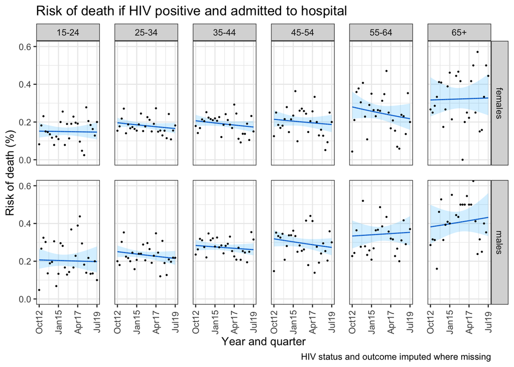

```r
label_sum <- spine_imp %>%
  filter(.imp==2, hiv=="Positive") %>%
  group_by(ageg10, sex) %>%
  summarise(sum = sum(n()), .groups="keep")

ggplot() +
  geom_line(data=death_out_risk_pos, aes(x = quarter, y = chance_death),color="#0066CC") +
  geom_ribbon(data=death_out_risk_pos, aes(x=quarter, ymin = conf.low, ymax = conf.high), alpha = 0.2, fill="#1AB8FF") +
  facet_grid(sex ~ ageg10) +
  geom_point(data=spine_outcome_gp %>% unnest(data) %>% filter(.imp==12), aes(x=quarter, y=risk_death),size=0.3) +
  #geom_text(data=label_sum, aes(x=ymd("2014-10-01"), y=0.7, label=paste0("n=",sum, sep="")), color="blue") +
  labs(title = "Risk of death if HIV positive and admitted to hospital",
         caption = "HIV status and outcome imputed where missing")+
  ylab("Risk of death (%)") +
  xlab("Year and quarter") +
  scale_x_date(breaks=breaks1, date_labels = "%b%y ") +
  coord_cartesian(ylim = c(0,0.6)) +
    theme_bw() %+replace%
  theme(panel.spacing = unit(1, "lines"),
        axis.text.x=element_text(angle = 90))
```

```r
ggsave(here("figures/fig_3.pdf"), width = 9, height = 6, dpi=300)

## What is trend line??
int_df2 <- death_risk_pos %>%
  ungroup() %>%
  filter(.imp == 12) %>% # NB. This is only one (of 25) models
  dplyr::select(model,data)
outcome_model <- int_df2[[1]][[1]]

x <- tidy(outcome_model, conf.int=TRUE)

emtrends(outcome_model, pairwise ~ ageg10|sex, var="q", data=int_df2[[2]][[1]], transform="response")
```

```
## $emtrends
## sex = females:
##  ageg10   q.trend       SE  df asymp.LCL asymp.UCL
##  15-24   0.000473 0.001164 Inf  -0.00181  2.75e-03
##  25-34  -0.001001 0.000827 Inf  -0.00262  6.19e-04
##  35-44  -0.001729 0.000912 Inf  -0.00352  5.84e-05
##  45-54  -0.001179 0.001357 Inf  -0.00384  1.48e-03
##  55-64  -0.003960 0.002045 Inf  -0.00797  4.93e-05
##  65+     0.000811 0.002758 Inf  -0.00460  6.22e-03
##
## sex = males:
##  ageg10   q.trend       SE  df asymp.LCL asymp.UCL
##  15-24  -0.000894 0.001654 Inf  -0.00414  2.35e-03
##  25-34  -0.001252 0.001045 Inf  -0.00330  7.97e-04
##  35-44  -0.001621 0.000925 Inf  -0.00343  1.93e-04
##  45-54  -0.001038 0.001339 Inf  -0.00366  1.59e-03
##  55-64   0.000503 0.002054 Inf  -0.00352  4.53e-03
##  65+     0.001555 0.002672 Inf  -0.00368  6.79e-03
##
## Confidence level used: 0.95
##
## $contrasts
## sex = females:
##  contrast           estimate      SE  df z.ratio p.value
##  (15-24) - (25-34)  0.001474 0.00143 Inf  1.032  0.9071
##  (15-24) - (35-44)  0.002202 0.00148 Inf  1.490  0.6710
##  (15-24) - (45-54)  0.001652 0.00179 Inf  0.924  0.9405
##  (15-24) - (55-64)  0.004432 0.00235 Inf  1.884  0.4122
##  (15-24) - (65+)   -0.000338 0.00299 Inf -0.113  1.0000
##  (25-34) - (35-44)  0.000729 0.00123 Inf  0.592  0.9916
##  (25-34) - (45-54)  0.000178 0.00159 Inf  0.112  1.0000
##  (25-34) - (55-64)  0.002959 0.00221 Inf  1.341  0.7620
##  (25-34) - (65+)   -0.001811 0.00288 Inf -0.629  0.9889
##  (35-44) - (45-54) -0.000551 0.00163 Inf -0.337  0.9994
##  (35-44) - (55-64)  0.002230 0.00224 Inf  0.996  0.9195
##  (35-44) - (65+)   -0.002540 0.00291 Inf -0.874  0.9527
##  (45-54) - (55-64)  0.002781 0.00245 Inf  1.133  0.8677
##  (45-54) - (65+)   -0.001989 0.00307 Inf -0.647  0.9874
##  (55-64) - (65+)   -0.004770 0.00343 Inf -1.389  0.7337
##
## sex = males:
##  contrast           estimate      SE  df z.ratio p.value
##  (15-24) - (25-34)  0.000358 0.00196 Inf  0.183  1.0000
##  (15-24) - (35-44)  0.000727 0.00190 Inf  0.384  0.9989
##  (15-24) - (45-54)  0.000144 0.00213 Inf  0.068  1.0000
##  (15-24) - (55-64) -0.001396 0.00264 Inf -0.530  0.9950
##  (15-24) - (65+)   -0.002449 0.00314 Inf -0.779  0.9711
##  (25-34) - (35-44)  0.000369 0.00140 Inf  0.264  0.9998
##  (25-34) - (45-54) -0.000214 0.00170 Inf -0.126  1.0000
##  (25-34) - (55-64) -0.001754 0.00230 Inf -0.761  0.9739
##  (25-34) - (65+)   -0.002806 0.00287 Inf -0.978  0.9250
##  (35-44) - (45-54) -0.000583 0.00163 Inf -0.358  0.9992
##  (35-44) - (55-64) -0.002123 0.00225 Inf -0.943  0.9354
##  (35-44) - (65+)   -0.003176 0.00283 Inf -1.123  0.8720
##  (45-54) - (55-64) -0.001541 0.00245 Inf -0.628  0.9890
##  (45-54) - (65+)   -0.002593 0.00299 Inf -0.867  0.9542
##  (55-64) - (65+)   -0.001052 0.00337 Inf -0.312  0.9996
##
## P value adjustment: tukey method for comparing a family of 6 estimates
```

```r
# reduction in admissions for every age and sex category (emtrends).
```

## 13. Sensitivity analysis (just those with known HIV)

```r
spine_gp_hivpos_orig <- spine %>%
 filter(hiv=="Positive") %>% # filter for HIV
  filter(is.na(outcome)==FALSE) %>% #filter out those with no outcome
  mutate(art=as.character(art)) %>%
  mutate(art=if_else(is.na(art)==TRUE,"no_art",art)) %>%  # add this bit here to make art "NAs" into no_art
  mutate(art=as.factor(art)) %>%
  ungroup() %>%
  mutate(q = group_indices(.,quarter)) %>%
  mutate(ageg10 = as.factor(ageg10)) %>%
  mutate(q = group_indices(.,quarter)) %>%
  group_by(q, quarter, ageg10, sex, hiv) %>% # NB. art statuds (deliberately) not here
  summarise(n_died= sum(outcome==1), n_alive=sum(outcome==0),n_all=n()) %>%
  mutate(odds_death = n_died/n_alive) %>%  # adding in outcome data I need
  mutate(risk_death = n_died/n_all)
b <- spine %>% filter(hiv=="Positive") %>%   mutate(q = group_indices(.,quarter))
death_risk_orig_pos <-glm(outcome ~ q*ageg10*sex,family=binomial(link="log"), data=b)
death_out_risk_pos <- model2pred_outcome_orig(b,death_risk_orig_pos)
```

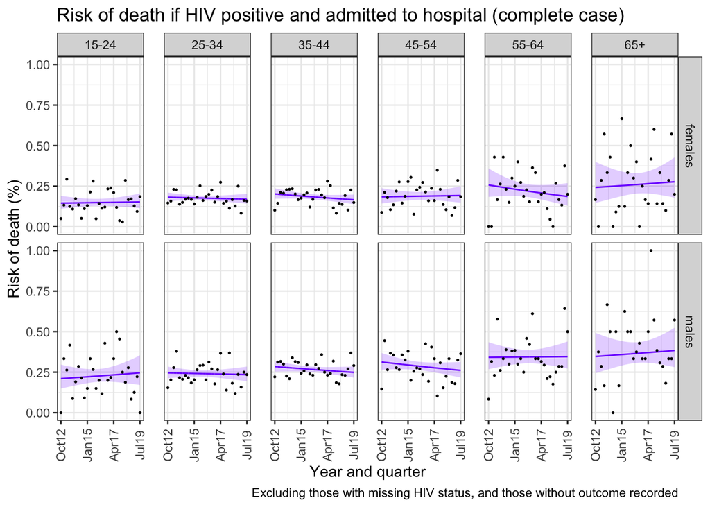

```r
ggplot() +
  geom_line(data=death_out_risk_pos, aes(x = quarter, y = chance_death),color="#7F00FF") +
  geom_ribbon(data=death_out_risk_pos, aes(x=quarter, ymin = conf.low, ymax = conf.high), alpha = 0.2, fill="#7F00FF") +
  facet_grid(sex ~ ageg10) +
  geom_point(data=spine_gp_hivpos_orig, aes(x=quarter, y=risk_death),size=0.3) +
  #geom_text(data=label_sum, aes(x=ymd("2014-10-01"), y=0.7, label=paste0("n=",sum, sep="")), color="blue") +
  labs(title = "Risk of death if HIV positive and admitted to hospital (complete case)",
       caption = "Excluding those with missing HIV status, and those without outcome recorded")+
  ylab("Risk of death (%)") +
  xlab("Year and quarter") +
  scale_x_date(breaks=breaks1, date_labels = "%b%y ") +
    theme_bw() %+replace%
  theme(panel.spacing.x=unit(0.5, "cm"),
        axis.text.x=element_text(angle = 90))
```

## 12. Does ART make any difference to these preductions?

```r
death_risk_pos_art <- spine_outcome_pos %>% mutate(model = list(glm(outcome ~ q*ageg10*sex*art, data = data,family=binomial(link="log")))) # add ART to illustrate / model (even though doesn't improve fit by AIC)

death_risk_pos <- spine_outcome_pos %>% mutate(model = list(glm(outcome ~ q*ageg10*sex, data = data,family=binomial(link="log")))) #log binomial to approximate risk rather than odds

model2pred_outcome_imp2 <- function(df,m){  ## This adds ART

  scaffold_df <-
  {if (".imp" %in% names(df)==TRUE) df %>% filter(.imp==1) %>% dplyr::select(-.imp) else df} %>%
  filter(hiv=="Positive") %>% #NB. keeping HIV pos only
  ungroup() %>%
   mutate(q = group_indices(.,quarter)) %>%
  expand(q, ageg10, sex,art)  ## add in ART here

  quarter <- spine_imp %>% filter(.imp==1,hiv=="Positive") %>%  mutate(q = group_indices(.,quarter)) %>% dplyr::select(q,quarter)

  predict_melded <- tibble(models = m$model) %>%
  ungroup() %>%
  mutate(m = 1:n(),
         fitted = models %>% map(~ augment(., newdata = scaffold_df, se_fit=TRUE))) %>% # this gives fit from each model (I think)
  unnest(fitted) %>%
  dplyr::select(m,q,sex,ageg10,art,.fitted,.se.fit) %>% # added in select to get rid of model df that was slowwing everything down....
  group_by(q, ageg10, sex) %>%  # Group by each of the variables that you vary
  nest(data= c(m, .fitted, .se.fit))  %>% # need to add 'm' here, otherwise nothing to meld over
  mutate(fitted_melded = data %>% map(~ meld_predictions(.))) %>%
  unnest(fitted_melded) %>%
  mutate(rmin = .fitted - (1.96 * .se.fit),
         rmax = .fitted + (1.96 * .se.fit))

response_scale <- predict_melded %>%
  mutate(chance_death = exp(.fitted),
         conf.low=exp(rmin),
         conf.high=exp(rmax)) %>%
  right_join(quarter)
response_scale
}

death_out_risk_pos_art <- model2pred_outcome_imp2(spine_imp,death_risk_pos_art)
models_art <- death_risk_pos_art %>% dplyr::select(model) %>% mutate(glanced=list(glance(model))) %>% unnest(glanced)
models_no_art <- death_risk_pos %>% dplyr::select(model) %>% mutate(glanced=list(glance(model))) %>% unnest(glanced)
models_no_art[["AIC"]] - models_art[["AIC"]]
```

```
##  [1] -27.133983 -24.977727 -17.677346 -26.128642 -16.079569 -12.033882
##  [7] -18.989024 -12.471187 -19.803370  -2.187998 -19.052459 -22.472079
## [13] -20.025041 -22.996147 -21.123174 -17.054793 -11.107067  -4.967115
## [19] -19.869775 -25.745373 -10.582003 -23.486528 -28.013457 -12.426191
## [25]  -9.115530
```

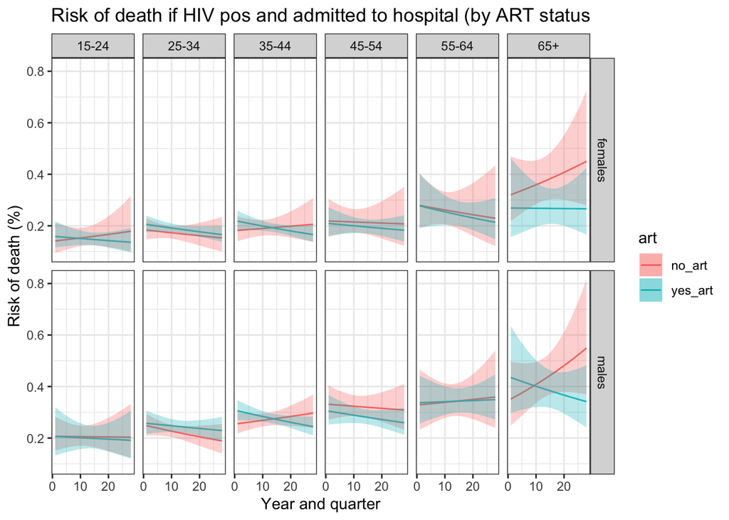

```r
# In every instance, models with no ART had lower AIC than models with ART included

ggplot() +
  geom_line(data=death_out_risk_pos_art%>%filter(art=="no_art"), aes(x = q, y = chance_death, color=art)) +
  geom_line(data=death_out_risk_pos_art%>%filter(art=="yes_art"), aes(x = q, y = chance_death, color=art)) +
  geom_ribbon(data=death_out_risk_pos_art%>%filter(art=="no_art"), aes(x = q, ymax = conf.high, ymin=conf.low, fill=art),alpha=0.3) +
  geom_ribbon(data=death_out_risk_pos_art%>%filter(art=="yes_art"), aes(x = q, ymax = conf.high,ymin=conf.low, fill=art),alpha=0.3) +
  facet_grid(sex ~ ageg10) +
  #geom_point(data=outcome_death %>% filter(hiv=="Positive",art=="yes_art"), aes(x=q, y=risk_death,color=art),size=0.3) +
    #geom_point(data=outcome_death %>% filter(hiv=="Positive",art=="no_art"), aes(x=q, y=risk_death,color=art),size=0.3) +
    #geom_text(data=n_no_art, aes(x=12, y=0.97,
                #label=paste0("no art=",n, sep=""))) +
      #geom_text(data=n_yes_art, aes(x=12, y=0.80,
                #label=paste0("yes art=",n, sep=""))) +
  ylab("Risk of death (%)") +
  xlab("Year and quarter") +
  labs(title = "Risk of death if HIV pos and admitted to hospital (by ART status") +
  theme_bw()
```